# Project One: Multiple Regression, Qualitative Variables Interactions, Quadratic Regression

For Project One, you have been asked to create different regression models analyzing a housing data set. Before beginning work on the project, be sure to read through the Project One Guidelines and Rubric to understand what you need to do and how you will be graded on this assignment. Be sure to carefully review the Project One Summary Report template, which contains all of the questions that you will need to answer about the regression analyses you are performing.

For this project, you will be writing all the scripts yourself. You may reference the textbook and your previous work on the problem sets to help you write the scripts.

### Scenario

You are a data analyst working for a real estate company. You have access to a large set of historical data that you can use to analyze relationships between different attributes of a house (such as square footage or the number of bathrooms) and the house’s selling price. You have been asked to create different regression models to predict sale prices for houses based on critical variable factors. These regression models will help your company set better prices when listing a home for a client. Setting better prices will ensure that listings can be sold within a reasonable amount of time.

There are several variables in this data set, but you will be working with the following important variables:

| Variable | What does it represent? |
| --- | --- |
| price | Sale price of the home |
| bedrooms | Number of bedrooms |
| bathrooms | Number of bathrooms |
| sqft_living | Size of the living area in sqft |
| sqft_above | Size of the upper level in sqft |
| sqft_lot | Size of the lot in sqft |
| age | Age of the home |
| grade | Measure of craftsmanship and the quality of materials used to build the home |
| appliance_age | Average age of all appliances in the home |
| crime | Crime rate per 100,000 people |
| backyard | Home has a backyard (backyard=1) or not (backyard=0) |
| view | Home backs out to a lake (view=2), backs out to trees (view=1), or backs out to a road (view=0) |

# Prepare Your Data Set

In the following code block, you have been given the R code to prepare your data set.

Click the **Run** button on the toolbar to run this code.

```r
housing <- read.csv(file="housing.csv", header=TRUE, sep=",")

# converting appropriate variables to factors
housing <- within(housing, {
   view <- factor(view)
   backyard <- factor(backyard)
})

# number of columns
ncol(housing)

# number of rows
nrow(housing)
```

22

2692

# Model #1 - First Order Regression Model with Quantitative and Qualitative Variables

You have been asked to create a first order regression model for *price* as the response variable, and *sqft_living*, *grade*, *bathrooms*, and *view* as predictor variables. Before writing any code, review Section 3 of the Summary Report template to see the questions you will be answering about your first order multiple regression model.

Run your scripts to get the outputs of your regression analysis. Then use the outputs to answer the questions in your summary report.

**Note: Use the + (plus) button to add new code blocks, if needed.**

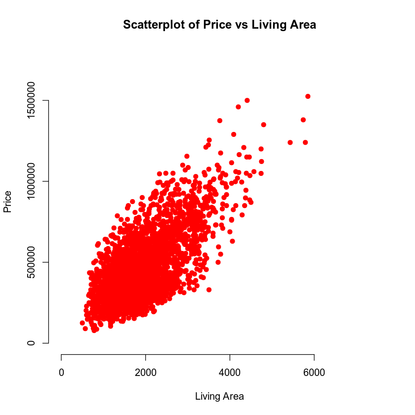

```r
plot(housing$sqft_living, housing$price,
     main = "Scatterplot of Price vs Living Area",
     xlab = "Living Area", ylab = "Price",
     xlim=c(0, 7500),
     ylim=c(0, 1750000),
     col="red",
     pch = 19, frame = FALSE)
```

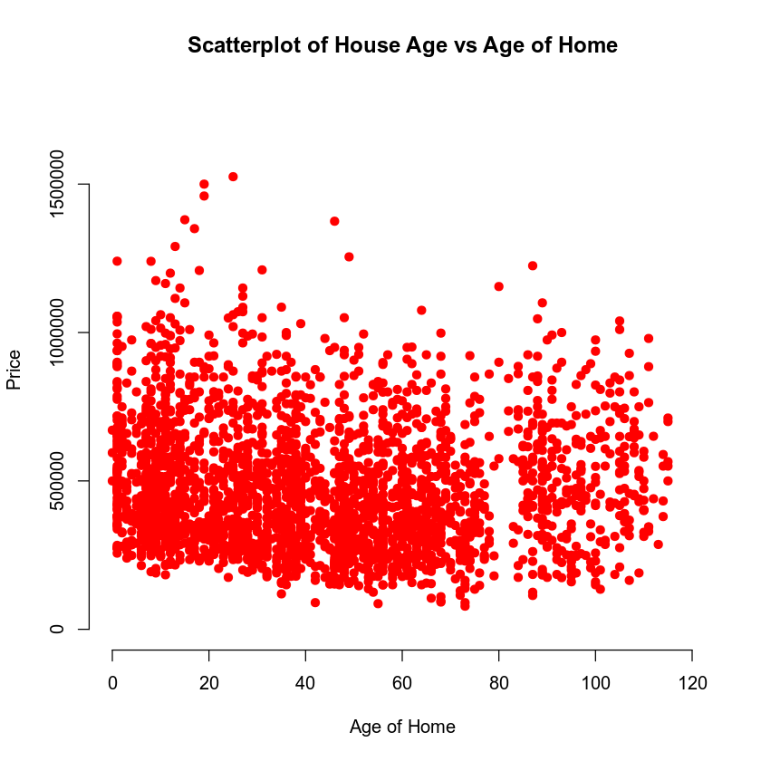

```r
plot(housing$age, housing$price,
     main = "Scatterplot of House Age vs Age of Home",
     xlab = "Age of Home", ylab = "Price",
     xlim=c(0, 120),
     ylim=c(0, 1750000),
     col="red",
     pch = 19, frame = FALSE)
```

```r
all_model <- lm(price ~ sqft_living + grade + bathrooms + view, data=housing)

summary(all_model)
```

```
Call:
lm(formula = price ~ sqft_living + grade + bathrooms + view,
    data = housing)

Residuals:
    Min      1Q  Median      3Q     Max
-378025  -91106   -8356   83217  383148

Coefficients:
              Estimate Std. Error t value Pr(>|t|)
(Intercept) -2.982e+05  2.118e+04 -14.083  < 2e-16 ***
sqft_living  9.384e+01  5.524e+00  16.986  < 2e-16 ***
grade        8.058e+04  3.574e+03  22.545  < 2e-16 ***
bathrooms   -2.182e+04  5.148e+03  -4.238 2.33e-05 ***
view1        1.657e+05  1.000e+04  16.559  < 2e-16 ***
view2        2.287e+05  1.134e+04  20.170  < 2e-16 ***
---
Signif. codes:  0 '***' 0.001 '**' 0.01 '*' 0.05 '.' 0.1 ' ' 1

Residual standard error: 125800 on 2686 degrees of freedom
Multiple R-squared:  0.6475,	Adjusted R-squared:  0.6469
F-statistic: 986.9 on 5 and 2686 DF,  p-value: < 2.2e-16
```

```r
housing_cor1 <- c("price","sqft_living")
housing_subset <- housing[housing_cor1]

corr_matrix <- cor(housing_subset, method = "pearson")
round(corr_matrix, 4)
```

A matrix: 2 × 2 of type dbl

|  | price | sqft_living |
| --- | --- | --- |
| price | 1.0000 | 0.6895 |
| sqft_living | 0.6895 | 1.0000 |

```r
housing_cor1 <- c("price","age")
housing_subset <- housing[housing_cor1]

corr_matrix <- cor(housing_subset, method = "pearson")
round(corr_matrix, 4)
```

A matrix: 2 × 2 of type dbl

|  | price | age |
| --- | --- | --- |
| price | 1.0000 | -0.0746 |
| age | -0.0746 | 1.0000 |

```r
resids1_allmod <- residuals(all_model)
resids1_allmod
```

**2**

10174.8981017104

**3**

119729.471574289

**4**

-11112.489057436

**5**

84363.46021515

**6**

-120709.767575074

**7**

-32976.3531579029

**8**

49336.0671857327

**9**

-173776.064225384

**10**

296442.165411164

**11**

-96287.7448054627

**12**

-79686.0949737667

**13**

-130244.478027102

**14**

-103671.787882891

**15**

-125885.023323088

**16**

70314.2548657352

**17**

-73191.52614057

**18**

-29129.562405959

**19**

65645.6087047152

**20**

-68240.6200297487

**21**

92403.9652921108

**22**

-219360.238852083

**23**

-36824.9240690685

**24**

55895.6068840469

**25**

130064.86101738

**26**

-65382.7466517934

**27**

97333.4992032964

**28**

-57377.9344839613

**29**

89126.5659267493

**30**

235219.123606784

**31**

-159908.786938646

**32**

-167801.070729525

**33**

25667.9870918043

**34**

166408.777459943

**35**

-107659.033831466

**36**

-13178.7857077587

**37**

245945.736296668

**38**

84837.520361884

**39**

265854.381816582

**40**

197999.786408632

**41**

96397.1088623806

**42**

110224.065187237

**43**

-53920.4233423772

**44**

-73645.4550221838

**45**

-170019.131264818

**46**

-217016.049965665

**47**

1967.11468375702

**48**

-157903.754343933

**49**

-105809.322763985

**50**

-164067.4589245

**51**

138236.819238662

**52**

-91098.4023934441

**53**

-118247.708868876

**54**

-142093.499211352

**55**

-52534.2003858991

**56**

-106091.509651907

**57**

-76265.6778595143

**58**

164702.760271494

**59**

292115.106089533

**60**

-84235.8078619165

**61**

-108919.667090157

**62**

87437.6686417906

**63**

169484.789460187

**64**

-46783.464821633

**65**

85420.4196416601

**66**

-89651.9449923393

**67**

-17387.3910086433

**68**

187991.657872433

**69**

-103340.513391636

**70**

-109858.053195048

**71**

71135.3517514662

**72**

58341.9606081364

**73**

-247707.67324827

**74**

241651.688620816

**75**

-236911.595793943

**76**

302655.233040379

**77**

8672.63850885189

**78**

299323.270536655

**79**

171534.502348337

**80**

124271.592418351

**81**

59848.0550076607

**82**

-165735.935453869

**83**

-73505.9744420116

**84**

-193267.101486344

**85**

-124339.811760554

**86**

22740.4811384248

**87**

109375.609935602

**88**

153479.847879734

**89**

-95041.2892250263

**90**

-115861.480134412

**91**

-204256.091922211

**92**

-213038.337338494

**93**

-68702.8081485581

**94**

77870.3039821289

**95**

-1342.77740017572

**96**

-59011.2761961939

**97**

-14145.618183418

**98**

5218.04981945616

**99**

208175.205343553

**100**

137843.24703912

**101**

-193346.061173829

**102**

-67115.0245539755

**103**

-27938.7479505034

**104**

-107022.610820081

**105**

-224979.895756798

**106**

181539.067673443

**107**

286352.066746926

**108**

31176.6289703818

**109**

26630.9354201512

**110**

-107953.055041379

**111**

-76702.796166042

**112**

85561.7458351379

**113**

-63834.4810786576

**114**

-41117.3922395305

**115**

179722.512147786

**116**

57773.5234494357

**117**

205583.994809606

**118**

152349.037464747

**119**

-69923.0940295211

**120**

-28995.6790904015

**121**

-162413.177120002

**122**

-47861.480134412

**123**

-169122.113393103

**124**

86942.7980287494

**125**

-50167.590157789

**126**

134475.074110263

**127**

50032.260147425

**128**

-198218.1506284

**129**

104138.77869083

**130**

7665.44339768915

**131**

-49021.1345773526

**132**

-27610.0829735224

**133**

-84529.1541725725

**134**

12489.1223758964

**135**

234683.994809606

**136**

-113378.11231319

**137**

118285.549669725

**138**

74919.0344131919

**139**

35981.0891620629

**140**

-134227.645551443

**141**

-161859.231749725

**142**

55009.2240916906

**143**

-69603.0325327564

**144**

-108837.769134753

**145**

3506.72699351461

**146**

189167.225061599

**147**

-99795.0540714707

**148**

-15231.0340924456

**149**

-35567.3295118787

**150**

83156.3449100871

**151**

-55349.4497148317

**152**

-97373.4721556311

**153**

-22112.000385993

**154**

-93430.1444702871

**155**

183342.351397002

**156**

-46041.5096519072

**157**

-5564.29081037779

**158**

-38344.8579738805

**159**

-218310.995104303

**160**

-28346.0611738289

**161**

-117847.173043537

**162**

-146910.172167114

**163**

33291.8399009533

**164**

167894.288024567

**165**

-49340.0842044095

**166**

-76567.5883371207

**167**

-67438.968693365

**168**

-110020.152120266

**169**

126129.154355166

**170**

113961.787874836

**171**

-23177.1322347259

**172**

-155050.616337087

**173**

-237267.317713933

**174**

84459.4243885719

**175**

93753.2735882109

**176**

-81695.4604841889

**177**

221942.798028749

**178**

58309.1838726611

**179**

-29821.2237709442

**180**

-93628.3126100713

**181**

-140460.014467885

**182**

-63665.4994723313

**183**

-128709.767575064

**184**

157976.094965711

**185**

195939.629914627

**186**

38911.6338169433

**187**

36345.8693506255

**188**

51233.4306976588

**189**

-72507.1008452377

**190**

22683.5883968879

**191**

-67088.945868762

**192**

-16006.9568990983

**193**

-189285.688561049

**194**

275464.193958752

**195**

-126055.596315902

**196**

102002.939880422

**197**

-114207.361491148

**198**

-100166.393115953

**199**

33623.359730247

**200**

-57828.1831974503

**201**

-52115.1438548435

**202**

56114.9766769116

**203**

-151113.49793037

**204**

256731.024613743

**205**

-183484.981283391

**206**

-91071.3796495049

**207**

-47512.2628525718

**208**

7446.86178498921

**209**

236830.450390042

**210**

-89948.0224466657

**211**

-261201.566866229

**212**

-141972.989262171

**213**

-43066.4380690518

**214**

101823.088192155

**215**

-144654.260061995

**216**

-44542.401094734

**217**

-84564.1613977568

**218**

83055.2750800772

**219**

-51895.9034745998

**220**

-43300.8486963896

**221**

-173318.70581732

**222**

-220950.428530582

**223**

78166.8752220965

**224**

-17008.1600990467

**225**

-62143.4992113521

**226**

377171.90781681

**227**

-188212.17365898

**228**

-138032.014728864

**229**

280290.103012315

**230**

15031.1138073343

**231**

-95188.3716450618

**232**

-108927.134055394

**233**

25245.4227188779

**234**

-121352.24962144

**235**

-55538.4608386533

**236**

-21923.3849311947

**237**

9238.20446712979

**238**

157241.631406494

**239**

7612.72647155631

**240**

73517.865970268

**241**

-154733.656403951

**242**

-33167.325870542

**243**

183647.563600642

**244**

-157908.916351267

**245**

54421.440497108

**246**

-26578.339076011

**247**

2555.76886571853

**248**

87072.1322010079

**249**

-68194.3086503743

**250**

-19199.3812091941

**251**

265527.284096589

**252**

-62166.611342039

**253**

50091.3424739752

**254**

-94562.5557424078

**255**

122244.453880405

**256**

-30316.0617636102

**257**

-79382.4878265514

**258**

135729.035644079

**259**

-85501.2532884394

**260**

-8696.84571265706

**261**

-133496.441120607

**262**

187583.907994637

**263**

81108.6882663514

**264**

-161592.791883599

**265**

-115951.410987669

**266**

-85453.7260573247

**267**

41530.7110359529

**268**

-9230.26007972374

**269**

116639.983711447

**270**

112451.530921587

**271**

41396.4736816023

**272**

196066.025818968

**273**

-148065.143854844

**274**

-169875.243058769

**275**

-186731.034092446

**276**

99721.5296906996

**277**

30867.006455386

**278**

-93407.8954958189

**279**

131721.229916094

**280**

-117931.165325735

**281**

92446.5893411336

**282**

35758.085756043

**283**

79760.8946113405

**284**

-21276.7258220078

**285**

-79264.1632184251

**286**

-40872.3602859234

**287**

-103226.351337235

**288**

127095.986830825

**289**

-56704.8643929722

**290**

83244.8905348755

**291**

61816.2727117882

**292**

32833.7479167854

**293**

261337.668641791

**294**

10088.4897583116

**295**

-28679.8065632065

**296**

-29438.1247522411

**297**

-173604.314764449

**298**

-60029.7828328399

**299**

231318.587781444

**300**

-157996.350106347

**301**

19391.9056160145

**302**

43251.7476558063

**303**

25477.4801941792

**304**

-141552.676915269

**305**

-94450.6489574627

**306**

-83159.9252742933

**307**

74539.9855321151

**308**

-95449.1343163735

**309**

186510.621302675

**310**

-125828.221595811

**311**

-8183.72728821179

**312**

166482.929178887

**313**

106217.651563347

**314**

-33665.6288849523

**315**

20366.1534109202

**316**

78649.1513036104

**317**

61894.5124087655

**318**

63781.5421297507

**319**

-52847.3934704176

**320**

-3573.87674768088

**321**

-67799.8662393029

**322**

85885.8668888513

**323**

-54984.5785120092

**324**

264415.969295846

**325**

-91349.6701417126

**326**

-77832.9953652824

**327**

234939.500502006

**328**

-109809.231749725

**329**

-216554.867215267

**330**

71956.3242221331

**331**

77424.3403666654

**332**

9987.33857533795

**333**

213948.90441079

**334**

143909.66890277

**335**

-24852.3252550984

**336**

-78738.6834021833

**337**

63212.9688081355

**338**

101576.946543973

**339**

132307.606884047

**340**

-157042.894880375

**341**

-183730.142649619

**342**

94057.9545227537

**343**

-165596.386113137

**344**

-180180.919347819

**345**

-72981.2809852663

**346**

-182630.678474958

**347**

72683.5883968879

**348**

-40998.9766171443

**349**

29015.2920753698

**350**

-3696.66368413729

**351**

-204870.42609447

**352**

74141.8173923309

**353**

-7585.73935627902

**354**

-211306.95507843

**355**

-40712.4607708304

**356**

136811.498942317

**357**

291816.272711788

**358**

13892.0642851516

**359**

25974.8917657626

**360**

180863.708928643

**361**

-17875.7488269261

**362**

159590.680877352

**363**

94753.7144419728

**364**

-36600.8084773602

**365**

-28932.8623113247

**366**

255656.78607983

**367**

-237172.229052634

**368**

-5270.74465329735

**369**

-17259.5188615752

**370**

84468.7515006329

**371**

-51378.0254982212

**372**

99207.1435680804

**373**

63634.9264714624

**374**

221933.216290737

**375**

58377.1765936662

**376**

174622.28594292

**377**

-231292.173069199

**378**

66942.8592645349

**379**

-193342.457748968

**380**

107754.567802419

**381**

-74944.8543325439

**382**

-130349.358700572

**383**

-50914.854922325

**384**

-62064.1613977568

**385**

210855.364273669

**386**

-84619.7983234465

**387**

-109847.302456158

**388**

112845.270797635

**389**

-57116.7215395652

**390**

-116072.362106592

**391**

-16306.95507843

**392**

107301.112576447

**393**

-158620.756451243

**394**

-11450.4285305818

**395**

23607.7968235246

**396**

179489.472215398

**397**

70478.4626512659

**398**

-1216.85641419132

**399**

199480.751305077

**400**

191919.125427452

**401**

14385.1048586455

**402**

25979.3540940928

**403**

36364.7297840909

**404**

-115473.496800903

**405**

151465.018716609

**406**

18801.1125764472

**407**

-84853.6386844015

**408**

-16934.8536413432

**409**

198247.569977552

**410**

127753.494015092

**411**

-69027.240959393

**412**

323629.154355166

**413**

215978.016019518

**414**

-109785.559148428

**415**

-157586.408551557

**416**

-30642.7371811463

**417**

-85524.7964771158

**418**

-182096.022725373

**419**

80152.9563690843

**420**

-57373.0313018693

**421**

-31930.4562274086

**422**

28015.2920753698

**423**

302067.449445797

**424**

-152937.012882533

**425**

40479.8478797341

**426**

8945.60688404685

**427**

-97638.567742652

**428**

-29540.7092233402

**429**

73683.8088237689

**430**

2313.4224578988

**431**

20225.5934469394

**432**

333966.561644307

**433**

181953.019146831

**434**

-41859.5678361372

**435**

-20845.0787167421

**436**

297745.422718878

**437**

-158558.184428337

**438**

-126171.696868632

**439**

90891.8819406511

**440**

-93829.6978385395

**441**

-235892.514933597

**442**

-25763.6694327838

**443**

-23785.6885610486

**444**

-165017.966463231

**445**

51241.5930081326

**446**

-28498.8856028845

**447**

106451.310494706

**448**

196869.095320175

**449**

-40028.7172021211

**450**

-161366.122670594

**451**

-32977.103307012

**452**

-175194.478027102

**453**

-65270.4900273464

**454**

170472.668026347

**455**

-84184.5081857032

**456**

-27595.5034387914

**457**

-170366.150907107

**458**

47768.8364949334

**459**

-115875.748826926

**460**

110393.30556748

**461**

-95692.0719431861

**462**

76095.147404973

**463**

60450.0162804975

**464**

-59221.9452533184

**465**

-26116.7215395652

**466**

-55573.8767476809

**467**

-128017.798652249

**468**

-213681.191791675

**469**

183860.683845756

**470**

68138.6492782091

**471**

112566.921461085

**472**

-57819.7758148242

**473**

-9904.10418343469

**474**

-173237.231488746

**475**

247840.836755913

**476**

151562.857704846

**477**

-51875.9575872717

**478**

249863.747327004

**479**

-147695.369469929

**480**

117165.710420509

**481**

81527.41350921

**482**

-29200.8006367323

**483**

-39567.4589244997

**484**

-156328.312610071

**485**

134666.875222097

**486**

-44768.0839434304

**487**

-17164.4786168834

**488**

-128254.797708003

**489**

-79416.005190394

**490**

28105.2613269875

**491**

-115534.291400159

**492**

155446.540924526

**493**

44098.2105702408

**494**

-174226.260322975

**495**

-72051.9661765893

**496**

192682.164770059

**497**

-189226.754108616

**498**

22928.6203504951

**499**

-55776.1552396443

**500**

-63038.0827125433

**501**

44411.0258446299

**502**

-62030.5911020347

**503**

-283442.357234368

**504**

167783.014173188

**505**

37087.2038852826

**506**

51454.6990357086

**507**

-63387.5204212644

**508**

17061.5250922763

**509**

-39430.1828686482

**510**

-129340.08420441

**511**

36473.6504834338

**512**

28671.6873899287

**513**

-179062.093751316

**514**

71662.010122385

**515**

-211979.895756798

**516**

66266.8752220965

**517**

-99622.8370249474

**518**

-120677.12025221

**519**

-82617.6750986315

**520**

126286.934898193

**521**

9863.21514300171

**522**

-121306.825665809

**523**

-269455.456926004

**524**

124170.302161461

**525**

-107302.051896338

**526**

-40390.8179480073

**527**

3054.65699601077

**528**

-44069.097119206

**529**

-86354.797708003

**530**

-200205.687330161

**531**

-27062.920115428

**532**

-130890.846234615

**533**

80652.1169432322

**534**

-7063.66761211545

**535**

-54823.9296294657

**536**

66451.3104947058

**537**

-19869.5514306258

**538**

3877.88660689732

**539**

3437.57367021335

**540**

-141517.83705061

**541**

-40690.9071415988

**542**

255651.532742255

**543**

-230361.559166156

**544**

-16825.9065261553

**545**

2053.87609851929

**546**

-98619.6689108255

**547**

-95482.1724280931

**548**

140508.203236243

**549**

265150.381559281

**550**

-9906.69261185127

**551**

-30455.8367896306

**552**

-140894.388833511

**553**

-46736.6993047435

**554**

105317.293567236

**555**

-203877.134055394

**556**

74286.9348981929

**557**

54301.7169074239

**558**

16221.5296906996

**559**

12404.2554555164

**560**

91459.3817909197

**561**

-126771.252057552

**562**

24231.9160565696

**563**

205128.292101032

**564**

199277.166616389

**565**

205033.143585809

**566**

55385.1048586455

**567**

42222.4211335264

**568**

-116518.281861689

**569**

240532.134662782

**570**

-249821.626542326

**571**

4650.42087254727

**572**

8762.00648104828

**573**

85611.0943502674

**574**

69138.519865588

**575**

-104396.885931687

**576**

96621.9745017788

**577**

210723.187363023

**578**

162451.348893067

**579**

-27267.590157789

**580**

72655.3240546393

**581**

-195606.914859401

**582**

-83022.5198058208

**583**

-108477.619085503

**584**

38841.4599541749

**585**

90366.0239982992

**586**

-18379.4491250505

**587**

188739.445749459

**588**

-261678.053734735

**589**

21555.6394530975

**590**

85380.2016765535

**591**

-152687.214268224

**592**

-91520.0753235436

**593**

11500.1319400288

**594**

140196.965646575

**595**

-147085.427915138

**596**

57165.8014347692

**597**

65290.1030123148

**598**

-220307.386136419

**599**

35785.3535721345

**600**

157924.443363441

**601**

-105116.005190394

**602**

63186.2149076849

**603**

50064.4201636185

**604**

-63665.1438548435

**605**

20645.7381173362

**606**

-119894.388833511

**607**

-18231.4122185556

**608**

-23423.9470739868

**609**

14763.3523962506

**610**

211120.302161461

**611**

-19510.3983719806

**612**

149511.630175607

**613**

-73493.0525796045

**614**

237242.796208081

**615**

-116757.074379298

**616**

26004.4119238584

**617**

-109404.261882664

**618**

-106584.13370093

**619**

23986.9367188613

**620**

-3643.34151212297

**621**

42348.0550076607

**622**

-60060.4994979936

**623**

8587.51276322988

**624**

-83133.4401763616

**625**

212284.255455516

**626**

-78262.0826447203

**627**

-37799.1324957051

**628**

129265.668380811

**629**

100459.38179092

**630**

37629.7340408712

**631**

-190638.567742652

**632**

-76371.1327566843

**633**

31177.884786229

**634**

-119206.470048321

**635**

30887.211167956

**636**

232006.18539019

**637**

5619.25666074125

**638**

71345.8693506255

**639**

108164.60037147

**640**

76947.6485949426

**641**

52963.211501665

**642**

63978.8654226474

**643**

-187681.191791675

**644**

216527.32249495

**645**

-126894.609260392

**646**

197250.776490035

**647**

353971.153385258

**648**

-88480.1444702871

**649**

-49448.5640499906

**650**

-178115.024553975

**651**

182597.85891007

**652**

219828.700838649

**653**

-123668.399341889

**654**

95882.8281873505

**655**

-42268.8459736362

**656**

66916.8607386729

**657**

-188505.974442012

**658**

64440.7417843352

**659**

242374.354119755

**660**

189288.717783847

**661**

-121779.232339506

**662**

-138252.288627311

**663**

-159046.192407118

**664**

-25017.8370506097

**665**

-86152.1654192202

**666**

-12335.3122556069

**667**

-39011.3672104538

**668**

8628.75158378444

**669**

-35342.9043807159

**670**

-105276.375982506

**671**

-14376.9136285134

**672**

-110641.68803909

**673**

-71606.5514012849

**674**

5633.43433899554

**675**

41185.9560824429

**676**

26676.1878006393

**677**

-196423.885602884

**678**

233555.639453098

**679**

-96768.0839434304

**680**

124820.99386536

**681**

16252.5115580051

**682**

92070.3116618011

**683**

-122196.292015603

**684**

167239.498681338

**685**

18287.79987508

**686**

247928.840777376

**687**

-71973.6983604978

**688**

-86908.9163512668

**689**

-303191.43512631

**690**

-69572.1416797108

**691**

-128952.705201877

**692**

134140.561576484

**693**

-57463.3119946278

**694**

-67324.3008708062

**695**

-80210.0162885532

**696**

42809.2222710222

**697**

140363.967753885

**698**

91485.9542617745

**699**

244511.630175607

**700**

36347.2545790937

**701**

-7141.06484082793

**702**

58692.0624644833

**703**

203032.680465398

**704**

-114387.520421264

**705**

41743.4194063433

**706**

16038.1134528699

**707**

28395.0445927679

**708**

115967.985271136

**709**

17480.3329098429

**710**

-28597.4199363573

**711**

-132995.458663521

**712**

-70251.5911955199

**713**

69037.7666905858

**714**

180422.955138197

**715**

-71584.4454580514

**716**

-143695.58989681

**717**

-37592.3608256099

**718**

155620.464059981

**719**

151709.758096361

**720**

-28006.9568990983

**721**

-196465.604025267

**722**

-34365.1420341752

**723**

23617.3827608276

**724**

-118189.561226397

**725**

93667.9870918044

**726**

49664.5985508015

**727**

76842.7980287493

**728**

94686.8859236308

**729**

-44093.7580365941

**730**

310925.452236373

**731**

-201200.584409143

**732**

327980.648308301

**733**

133228.929970968

**734**

-23989.7892519316

**735**

-63954.3384605675

**736**

-25314.2926310461

**737**

204031.887820056

**738**

171522.380914497

**739**

144340.875154274

**740**

835.482984755506

**741**

7712.03476765638

**742**

-153251.356441097

**743**

26094.5105880971

**744**

76996.4700402656

**745**

330849.531250389

**746**

-108118.557041118

**747**

132091.437687526

**748**

-125555.675347645

**749**

2557.42653804234

**750**

-121295.171501576

**751**

23298.5625463917

**752**

-28883.7291088801

**753**

47547.8269821257

**754**

-122763.401188219

**755**

-128631.881674906

**756**

-142644.856153212

**757**

-142935.134783329

**758**

56731.9160565696

**759**

26633.6547658764

**760**

211203.819525303

**761**

-14284.4472787198

**762**

-229858.053195048

**763**

237103.075669952

**764**

-58133.122957235

**765**

-51456.4611252948

**766**

270446.289566528

**767**

115882.26771674

**768**

27116.2708911199

**769**

-125810.616978193

**770**

150299.961578044

**771**

-43416.9667920328

**772**

-111055.323872046

**773**

72754.6588166791

**774**

32746.5875204652

**775**

-28373.1223161292

**776**

70009.0420631708

**777**

-124340.213617031

**778**

-10438.2541648621

**779**

96143.3320334201

**780**

185699.280716231

**781**

-205241.914243957

**782**

-56747.6178546159

**783**

-64205.4875912345

**784**

-54332.1039224555

**785**

-188600.586229811

**786**

227432.411662879

**787**

-27186.8954023337

**788**

83329.6109641904

**789**

200336.067185733

**790**

193524.604653913

**791**

69503.0002795451

**792**

138649.035644079

**793**

289331.977013648

**794**

72947.2037838633

**795**

-362989.536396554

**796**

-263824.924069069

**797**

128852.958189753

**798**

116626.65725699

**799**

138938.024259278

**800**

50659.9157955905

**801**

46974.8253967741

**802**

184595.004373738

**803**

12792.5591611274

**804**

-206056.852131749

**805**

-77646.7186916078

**806**

58141.946804952

**807**

161642.799849418

**808**

-127561.48195508

**809**

285611.146966166

**810**

-191559.478642546

**811**

-173915.299733404

**812**

-60873.2133303891

**813**

200857.511532343

**814**

-111757.074379298

**815**

-119107.935714848

**816**

-20416.0051903939

**817**

159146.504346833

**818**

72382.9695824875

**819**

-63725.5509086675

**820**

-67000.3618456125

**821**

23622.4247748631

**822**

67979.9772923552

**823**

-13121.9839804817

**824**

-38858.7786988858

**825**

-75852.0436309156

**826**

-15570.4392999389

**827**

-166313.55706678

**828**

-228141.194253449

**829**

-54013.1542953986

**830**

-162995.54967778

**831**

-3405.295400867

**832**

-59948.2428735466

**833**

72226.0950158056

**834**

117603.979095295

**835**

27404.7657206778

**836**

-18520.1137219048

**837**

-113594.472249116

**838**

-228337.989877615

**839**

-169858.053195048

**840**

-60810.6169781932

**841**

-169122.204407363

**842**

67508.3326488637

**843**

-126216.492956076

**844**

108217.517951434

**845**

226074.006100922

**846**

106367.681670623

**847**

-70721.5391694024

**848**

-129930.182868648

**849**

222127.560366352

**850**

164921.672906505

**851**

72689.7857931882

**852**

8656.61826884757

**853**

-152585.427915138

**854**

-49477.1304140576

**855**

-252106.823845141

**856**

-101470.271421134

**857**

90766.1570522569

**858**

129133.875508738

**859**

-205606.914859401

**860**

31914.4426722408

**861**

187815.237322822

**862**

-105238.252344194

**863**

57413.5896277751

**864**

-22695.5201602852

**865**

12155.0932128656

**866**

-34473.9717192582

**867**

59708.8666535345

**868**

188192.062464483

**869**

302547.177368018

**870**

-52000.2708313526

**871**

-136657.648602998

**872**

-25212.549323316

**873**

-52979.8957567981

**874**

304811.719369198

**875**

20740.4811384248

**876**

-239018.910837937

**877**

-68079.4509457188

**878**

-17539.2329806122

**879**

-227994.856062608

**880**

-102781.176167822

**881**

-138667.01411342

**882**

-197313.613589902

**883**

215265.17459517

**884**

-130188.371645062

**885**

-76355.8675380129

**886**

92065.6665601431

**887**

-85600.8084773601

**888**

20295.1356070278

**889**

-43453.6876589635

**890**

-231104.508775484

**891**

-22469.509390928

**892**

-67561.4819550803

**893**

61649.0356440791

**894**

-78043.3835518208

**895**

-16104.5087754845

**896**

2353.26994687424

**897**

-34543.8773374621

**898**

-205071.094308228

**899**

-21555.7592531365

**900**

-16660.8167171201

**901**

178997.323084731

**902**

87773.6486627655

**903**

270091.342473975

**904**

8746.58752046521

**905**

-170032.144141485

**906**

51970.0795979305

**907**

-143524.796477116

**908**

77573.0236438348

**909**

152419.699651152

**910**

-185824.794656447

**911**

-170404.506954816

**912**

-102374.545942958

**913**

-147737.993518952

**914**

96316.0239982992

**915**

79617.1623339467

**916**

43323.4909635364

**917**

-14697.0135236392

**918**

156241.065339402

**919**

101142.591405053

**920**

-58981.5014121471

**921**

-168270.153940934

**922**

-80676.6384490846

**923**

-27197.775553845

**924**

-13597.6019648771

**925**

-123387.520421264

**926**

-61012.3541828124

**927**

165541.461774843

**928**

290778.460830598

**929**

68670.7959471018

**930**

110319.711633668

**931**

131664.311438951

**932**

137626.877683871

**933**

-10250.9033988428

**934**

-106480.775217109

**935**

258884.896414281

**936**

-133597.419936357

**937**

182982.239746113

**938**

73829.5306606075

**939**

-80587.6135721733

**940**

148033.208134129

**941**

-32297.2013301448

**942**

-183346.58915854

**943**

-77477.489672882

**944**

21966.3796157869

**945**

118937.314844971

**946**

2010.51830589883

**947**

-146012.08264472

**948**

-122078.958074982

**949**

108174.984916672

**950**

70076.4995577608

**951**

-284042.298097958

**952**

-111091.404884558

**953**

174959.811242654

**954**

-14510.5277846017

**955**

46276.0547466816

**956**

226479.847879734

**957**

-5818.6882744071

**958**

38600.2668146548

**959**

68663.7491476725

**960**

228752.66717068

**961**

45739.0048956968

**962**

18893.0587247544

**963**

-217875.657812666

**964**

-201380.35353565

**965**

-132159.925274293

**966**

-17727.2427800614

**967**

277726.432872792

**968**

-118837.457693613

**969**

-9687.38918797498

**970**

-71420.6495472439

**971**

115415.554541949

**972**

-33635.49064279

**973**

4473.42063723049

**974**

37439.5005020064

**975**

56837.5392291696

**976**

-66399.6338299059

**977**

237606.975707004

**978**

86878.0160195183

**979**

-311803.309482759

**980**

-127490.270140152

**981**

-52932.3685256833

**982**

-293786.944376896

**983**

187549.700882039

**984**

-95068.5707942075

**985**

127359.038155948

**986**

-220498.548756818

**987**

90735.9277958348

**988**

59316.2727117882

**989**

-19138.7254418811

**990**

69680.8705558503

**991**

224536.558592751

**992**

-149458.538225157

**993**

86214.3114389514

**994**

-53583.242258103

**995**

-85432.8376660533

**996**

42783.0141731877

**997**

-308416.755238084

**998**

216923.058134973

**999**

49840.1657399666

**1000**

98299.6363337191

**1001**

325743.817063529

**1002**

-58331.8834955746

**1003**

60802.5837049794

**1004**

-115600.7174631

**1005**

-125013.024882778

**1006**

24609.1820519927

**1007**

53299.9477748599

**1008**

-18297.4217570257

**1009**

45607.4814250663

**1010**

-196155.113106461

**1011**

81310.879943346

**1012**

-32946.8192467173

**1013**

-39830.5892813663

**1014**

-84544.9511247895

**1015**

-199712.909008833

**1016**

38527.41350921

**1017**

-98930.0534560272

**1018**

38392.816896035

**1019**

-102681.282805935

**1020**

-36021.1345773526

**1021**

-82836.1634794042

**1022**

-103667.10512768

**1023**

-60251.370768639

**1024**

116045.871171294

**1025**

98418.2723829861

**1026**

-5684.70974529853

**1027**

-22610.7316177219

**1028**

134160.558524928

**1029**

83458.0875767114

**1030**

122525.425390307

**1031**

-211306.95507843

**1032**

76704.5431571478

**1033**

-152823.405228688

**1034**

21222.2917209054

**1035**

109650.641299428

**1036**

64098.3019004814

**1037**

-118715.873957105

**1038**

157796.027049855

**1039**

-59845.5673881876

**1040**

-181384.131880261

**1041**

22318.8082083253

**1042**

-76671.7352669926

**1043**

71786.3116999306

**1044**

-80743.0261136647

**1045**

-68512.0424256909

**1046**

-139241.914243957

**1047**

-94830.6156972115

**1048**

150097.539870276

**1049**

37978.8654226474

**1050**

-95264.1632184251

**1051**

-220930.02091667

**1052**

-11460.8148964518

**1053**

-163373.122316129

**1054**

-39262.1983042516

**1055**

-24402.9923137269

**1056**

-35066.0617135155

**1057**

-53905.4894119029

**1058**

213542.365200186

**1059**

-99472.806917671

**1060**

-78427.738386371

**1061**

-173269.775814824

**1062**

272230.49242974

**1063**

140233.392299298

**1064**

75753.2735882109

**1065**

32368.233984625

**1066**

-47912.4223724692

**1067**

-46245.3027849598

**1068**

-133885.114337348

**1069**

-163983.844768411

**1070**

-86904.0131691748

**1071**

-49830.4598687453

**1072**

-53543.0200937053

**1073**

158740.610551046

**1074**

8453.71626264109

**1075**

118677.611427469

**1076**

240198.748532229

**1077**

-149430.182868648

**1078**

-9416.00519039394

**1079**

-114746.882240255

**1080**

158107.926236146

**1081**

9304.63053007102

**1082**

-39252.549323316

**1083**

-28155.3719317032

**1084**

65113.5914484434

**1085**

-56466.3412768061

**1086**

15336.8192386616

**1087**

-147962.86536288

**1088**

-132036.697484075

**1089**

-158905.489411903

**1090**

-57281.7678360433

**1091**

-49587.0885779578

**1092**

43378.7515837844

**1093**

-36476.1044444139

**1094**

-208128.272391042

**1095**

60212.8351962234

**1096**

-98371.3661108288

**1097**

129516.317130109

**1098**

-161875.657812666

**1099**

-210089.36391847

**1100**

-50690.6867147179

**1101**

94520.9956860288

**1102**

-39675.6175936368

**1103**

122407.353833114

**1104**

187043.647431878

**1105**

158909.66890277

**1106**

115242.925620702

**1107**

92488.6837693474

**1108**

149235.589938849

**1109**

17524.3884263227

**1110**

-42687.389187975

**1111**

183830.450390042

**1112**

-128864.375804678

**1113**

50287.4235696383

**1114**

-19199.3812091941

**1115**

51747.828802794

**1116**

-38927.738386371

**1117**

-31013.1542953986

**1118**

209533.970164335

**1119**

185897.767895811

**1120**

130414.728013517

**1121**

-73118.6864537388

**1122**

-5448.5120330159

**1123**

127432.411662879

**1124**

-56542.401094734

**1125**

-6082.25980101631

**1126**

-162141.064840828

**1127**

-167875.748826926

**1128**

17640.9643478652

**1129**

208699.15130361

**1130**

135244.803719907

**1131**

-17850.3411576585

**1132**

-24573.6563208

**1133**

-121251.409167

**1134**

27903.5625207294

**1135**

-114977.489672882

**1136**

126661.698681244

**1137**

67596.890256168

**1138**

-32042.6498082231

**1139**

-292110.615157525

**1140**

16203.5607000611

**1141**

-140676.638449085

**1142**

-72987.8760387521

**1143**

-203311.59943528

**1144**

60285.6790823457

**1145**

123427.508480787

**1146**

19323.3615509154

**1147**

-200408.68394187

**1148**

75456.3046910577

**1149**

-177444.10172166

**1150**

32507.7608167352

**1151**

126012.612632693

**1152**

-118719.171483847

**1153**

143606.723036197

**1154**

-153359.634521106

**1155**

14277.0756021294

**1156**

-205081.056601068

**1157**

-70501.1238758184

**1158**

-44130.1846893166

**1159**

-61042.6744534944

**1160**

-20895.6830477188

**1161**

50484.4780190464

**1162**

201108.688266351

**1163**

82025.2798691496

**1164**

93098.1724878603

**1165**

32245.8323585795

**1166**

28880.3347305112

**1167**

125716.846935488

**1168**

99733.5601102798

**1169**

-95055.5579175405

**1170**

85602.3719236475

**1171**

-68218.4620695404

**1172**

-32265.7162578755

**1173**

-33669.6689108255

**1174**

-52591.093127436

**1175**

125816.402124409

**1176**

32194.0657770179

**1177**

32424.3403666654

**1178**

26338.9440292223

**1179**

150707.299396547

**1180**

-7917.34115765854

**1181**

-120327.200740364

**1182**

-189908.657526025

**1183**

-142560.228690235

**1184**

159399.2825369

**1185**

2509.31510595044

**1186**

104868.430082215

**1187**

49001.1143971155

**1188**

-86006.9568990983

**1189**

35982.1629493903

**1190**

49775.2927164757

**1191**

169093.631127786

**1192**

-114667.893573731

**1193**

15065.0433618808

**1194**

56325.8096745292

**1195**

-57387.2999943835

**1196**

33544.7976999473

**1197**

82367.902097504

**1198**

191655.233040379

**1199**

-132363.756805707

**1200**

99087.5247457459

**1201**

109337.53922917

**1202**

-153967.103307012

**1203**

6983.27481909806

**1204**

-231469.288964047

**1205**

-25278.4703093004

**1206**

-114454.48808753

**1207**

-7374.85738409928

**1208**

60792.7295231118

**1209**

69361.0414684827

**1210**

-16420.7405615038

**1211**

189132.49028027

**1212**

231142.167231833

**1213**

-224584.536472311

**1214**

20192.5511359287

**1215**

-30983.4546597854

**1216**

-94312.1983042517

**1217**

-184632.698714962

**1218**

-178933.844768411

**1219**

118809.897486259

**1220**

-52226.8871625736

**1221**

75020.9673994207

**1222**

-135055.6489318

**1223**

72968.114683757

**1224**

-142077.044861803

**1225**

135710.740553448

**1226**

-11959.5206822435

**1227**

74850.0199218342

**1228**

-198353.769011927

**1229**

-54621.9839804817

**1230**

-167421.943761452

**1231**

-302088.933886246

**1232**

39383.8106444372

**1233**

-142912.084465389

**1234**

281175.075930932

**1235**

112600.115451366

**1236**

-52423.2133303891

**1237**

67562.2345065833

**1238**

-33567.1864806441

**1239**

-82742.6762741628

**1240**

202634.857965825

**1241**

-126502.858943788

**1242**

-115636.020263599

**1243**

204973.108880109

**1244**

251269.948364641

**1245**

31777.5538140143

**1246**

-24444.3605469025

**1247**

97412.0365883247

**1248**

158474.000322936

**1249**

2880.44856937416

**1250**

-162000.361845613

**1251**

-94325.7771135342

**1252**

-10461.7063392786

**1253**

186732.898513656

**1254**

197460.767019388

**1255**

-38183.6888898507

**1256**

-171869.395337651

**1257**

-73814.1349318171

**1258**

-172526.311118205

**1259**

112914.351657981

**1260**

15863.708928643

**1261**

-171465.685539187

**1262**

-59947.9067871344

**1263**

120918.090038486

**1264**

57198.6575179691

**1265**

-34021.4343519581

**1266**

-145192.963386013

**1267**

-148093.265165858

**1268**

-56623.0958501894

**1269**

-7655.10764445613

**1270**

23901.6886208158

**1271**

-151321.132756684

**1272**

-176725.647726576

**1273**

12851.5729612845

**1274**

116001.373222358

**1275**

88046.3089350166

**1276**

-172197.775553845

**1277**

-54608.5683324332

**1278**

-114956.09374288

**1279**

135219.214621043

**1280**

-27533.694786984

**1281**

76269.8573503813

**1282**

170217.522150726

**1283**

153087.642175851

**1284**

33271.3719914705

**1285**

-56124.1576550008

**1286**

-112266.985826812

**1287**

-86484.8272254982

**1288**

20752.2911311242

**1289**

142454.569623088

**1290**

127102.802311192

**1291**

138584.474061729

**1292**

234558.850164872

**1293**

61179.6718711738

**1294**

215001.152795477

**1295**

245266.780250519

**1296**

27138.519865588

**1297**

154650.459270908

**1298**

25072.261613629

**1299**

100176.590572021

**1300**

227179.888098764

**1301**

8581.31536692959

**1302**

-110381.857029635

**1303**

-142982.367294796

**1304**

83993.0431009016

**1305**

-136867.457103831

**1306**

1856.28036176699

**1307**

201816.181697528

**1308**

-16623.3120777792

**1309**

-84087.2108007919

**1310**

-161795.145085731

**1311**

-77991.7967637573

**1312**

-26873.2133303891

**1313**

305051.086110507

**1314**

68222.6415604073

**1315**

-41226.3129388734

**1316**

-28332.0655240944

**1317**

-118296.116181299

**1318**

-106012.458950162

**1319**

-239207.270476888

**1320**

-38520.1521202659

**1321**

43160.8072384173

**1322**

-52794.4620872687

**1323**

25337.5776275308

**1324**

-35452.4318431164

**1325**

-137698.756190263

**1326**

210906.241963406

**1327**

93707.2225998243

**1328**

-269242.259884168

**1329**

-7330.07596464953

**1330**

43470.7506138765

**1331**

183299.727347979

**1332**

-158600.835209186

**1333**

-83963.5607081168

**1334**

-205886.537964178

**1335**

89635.9560824429

**1336**

85709.9596559566

**1337**

-148365.142034175

**1338**

-153730.142649619

**1339**

-197110.212386143

**1340**

149932.5410755

**1341**

81602.5800636427

**1342**

-193534.32979852

**1343**

-75829.6068242796

**1344**

27137.2640497409

**1345**

81139.7731304329

**1346**

359299.94777486

**1347**

109286.934898193

**1348**

-55188.3716450617

**1349**

98784.1260428954

**1350**

-43842.3992740657

**1351**

-145027.202561032

**1352**

-5829.61046561629

**1353**

-185578.468488632

**1354**

34544.8545151372

**1355**

36484.6984459274

**1356**

85031.4730661587

**1357**

34014.3997176383

**1358**

100963.330802533

**1359**

-25180.3003488479

**1360**

187418.233984625

**1361**

61840.0132289421

**1362**

-99935.8360984301

**1363**

-131951.54040029

**1364**

-77419.1733045158

**1365**

181843.554280969

**1366**

170208.118241942

**1367**

-142520.022707645

**1368**

-165321.132756684

**1369**

-81535.660321508

**1370**

-80143.1074666285

**1371**

58439.2517885174

**1372**

-33135.4522444289

**1373**

60176.4995577608

**1374**

-168065.273267465

**1375**

-139430.182868648

**1376**

91808.8194996408

**1377**

180735.577956333

**1378**

77162.022104901

**1379**

-80829.1920703821

**1380**

61192.0624644833

**1381**

-55742.8056867838

**1382**

-3995.58807614155

**1383**

75658.6599797433

**1384**

82133.8755087381

**1385**

-14521.5373487341

**1386**

76857.6433810757

**1387**

108715.293896038

**1388**

-88847.3024561577

**1389**

-149766.698714962

**1390**

227247.263173318

**1391**

159756.354887364

**1392**

-75635.4522444289

**1393**

29084.1242222271

**1394**

83208.1182419423

**1395**

14988.7313225227

**1396**

-101531.74046434

**1397**

-136637.273528444

**1398**

56782.2128297159

**1399**

-28452.4318431164

**1400**

-10050.0120061106

**1401**

122744.621375406

**1402**

-36027.3319736529

**1403**

27149.6588423414

**1404**

210366.478470675

**1405**

254099.919538346

**1406**

-161875.657812666

**1407**

-36316.282190491

**1408**

-185810.616978193

**1409**

-37828.0921831904

**1410**

4316.27271178821

**1411**

40161.1433248295

**1412**

-129837.678120493

**1413**

277768.836494933

**1414**

164707.352012445

**1415**

18823.229587292

**1416**

-207889.83549092

**1417**

65967.985271136

**1418**

-46251.4091670002

**1419**

61453.6781802607

**1420**

37634.9489800847

**1421**

-1842.49028832558

**1422**

-81567.5499387596

**1423**

191800.839217687

**1424**

-28470.5302463759

**1425**

266916.860738673

**1426**

-33170.8054258047

**1427**

-70254.2564206588

**1428**

140519.485244231

**1429**

-80528.7172021211

**1430**

-30811.2993961662

**1431**

-175888.210263987

**1432**

-32829.7746774223

**1433**

-216559.387628286

**1434**

-92717.6184443972

**1435**

-84415.5201602852

**1436**

111533.51989125

**1437**

-205832.261621685

**1438**

99541.5911874643

**1439**

66402.5800636427

**1440**

-154472.806917671

**1441**

-44384.2228945214

**1442**

112862.232685915

**1443**

283740.610551046

**1444**

113557.954522754

**1445**

126645.867529957

**1446**

-38552.3839444147

**1447**

58299.727347979

**1448**

46982.0335367693

**1449**

-196723.94343265

**1450**

1110.6531805249

**1451**

26177.884786229

**1452**

-252671.40979729

**1453**

18656.6182688476

**1454**

47414.8308161368

**1455**

47451.5309215867

**1456**

22999.6381543875

**1457**

189415.152086548

**1458**

-16253.2830669137

**1459**

112740.481138425

**1460**

160477.752322054

**1461**

-180278.4703093

**1462**

244693.174334191

**1463**

74152.6975438423

**1464**

-107203.428783627

**1465**

24163.5229428058

**1466**

-58785.6885610486

**1467**

-130389.954791789

**1468**

151694.195189639

**1469**

-47553.4106588664

**1470**

142660.898252677

**1471**

-6175.39716675587

**1472**

536.558592751238

**1473**

32416.9781687779

**1474**

127517.736557647

**1475**

-74243.7881438706

**1476**

65470.3003407922

**1477**

69539.9855321151

**1478**

93094.3853747673

**1479**

-26777.3584395927

**1480**

-40262.3998815752

**1481**

109208.708954305

**1482**

102644.223476247

**1483**

-20107.8063022274

**1484**

-61354.3912952848

**1485**

224048.589012331

**1486**

-193344.766959621

**1487**

-89510.7482114826

**1488**

126853.676359592

**1489**

-196900.936069313

**1490**

-137477.619085503

**1491**

-155306.825665809

**1492**

31006.9210045504

**1493**

-24004.0050125662

**1494**

-38199.1607823132

**1495**

-104325.906526155

**1496**

139693.174334191

**1497**

-113213.065101807

**1498**

-28309.480463214

**1499**

362655.233040379

**1500**

-116883.573015906

**1501**

-217875.657812666

**1502**

311660.045208211

**1503**

-155753.412479535

**1504**

69925.3228237522

**1505**

-15423.5878151624

**1506**

-91507.2302578588

**1507**

-121444.322148541

**1508**

-114971.474621082

**1509**

38313.9960404932

**1510**

-42804.3931159532

**1511**

-219734.73439057

**1512**

35485.173364283

**1513**

-101603.176478896

**1514**

64462.0732161122

**1515**

372290.361837557

**1516**

80928.4041229053

**1517**

99495.1494102122

**1518**

-98687.9043253602

**1519**

19294.2919818845

**1520**

224492.68583665

**1521**

-126406.95507843

**1522**

63348.548793302

**1523**

-105748.847154429

**1524**

-11866.6987149622

**1525**

114667.766664923

**1526**

137903.342093849

**1527**

129119.568417863

**1528**

-16547.174864205

**1529**

57844.7574809178

**1530**

-99012.8044558967

**1531**

-133956.09374288

**1532**

-40861.480134412

**1533**

153408.777459943

**1534**

-88460.9323265568

**1535**

-19152.3741795658

**1536**

-100008.030686426

**1537**

18048.5506139704

**1538**

41562.232685915

**1539**

82700.1721590583

**1540**

-10068.5707942074

**1541**

-15113.4979303703

**1542**

39009.7298598479

**1543**

-207373.031301869

**1544**

-253848.596670366

**1545**

-8283.06205025161

**1546**

99370.9271803912

**1547**

-8597.41993635734

**1548**

122759.691411392

**1549**

1844.62806829677

**1550**

162878.869063984

**1551**

-117259.389448954

**1552**

-1487.10202603021

**1553**

-37497.9557616965

**1554**

-62752.5210367079

**1555**

-107827.044861803

**1556**

-144076.373845857

**1557**

226740.519536786

**1558**

-7813.91450493611

**1559**

-12848.4672577449

**1560**

90593.6191452703

**1561**

-154963.566526612

**1562**

-160901.971458279

**1563**

24637.5374085013

**1564**

-241837.587106234

**1565**

-100220.556712316

**1566**

-118806.063635603

**1567**

8003.20508257335

**1568**

68034.1909071963

**1569**

-17227.6190855031

**1570**

-88785.3387215466

**1571**

54336.2834133225

**1572**

99998.434954439

**1573**

34816.1816975283

**1574**

129290.812110641

**1575**

-220556.090101543

**1576**

29192.9658898261

**1577**

68660.0452082115

**1578**

-176777.358439593

**1579**

-206454.747827677

**1580**

-158842.269861445

**1581**

-65143.8736961254

**1582**

-162913.177120002

**1583**

-25771.3814701733

**1584**

-140444.360546902

**1585**

127138.519865588

**1586**

220325.45587771

**1587**

-16731.1515225506

**1588**

-96618.532711827

**1589**

-135131.478903525

**1590**

197081.809152571

**1591**

-335684.925972888

**1592**

48040.4793177565

**1593**

84068.8346742651

**1594**

-147692.292370067

**1595**

-125453.817071585

**1596**

-84328.3408966794

**1597**

147664.598550802

**1598**

-22143.8736961254

**1599**

-150828.312610071

**1600**

202754.658816679

**1601**

-61052.1693765376

**1602**

120345.739938005

**1603**

-54387.8760387521

**1604**

-152458.499826796

**1605**

68020.013228942

**1606**

153132.542896169

**1607**

-41643.470924744

**1608**

-25690.8161273389

**1609**

-125450.390132221

**1610**

111283.014173188

**1611**

-65571.5976146116

**1612**

55034.2819214562

**1613**

-57157.4586635205

**1614**

-235838.972334702

**1615**

284877.886606897

**1616**

-196720.647726576

**1617**

-8428.17955611358

**1618**

10809.0663924614

**1619**

-95196.2609127558

**1620**

175500.131940029

**1621**

-121055.778344421

**1622**

179678.996655937

**1623**

-170971.656649602

**1624**

158581.31536693

**1625**

116276.568063398

**1626**

512.924389814882

**1627**

65772.2634342973

**1628**

126620.900714451

**1629**

-120022.610820081

**1630**

127381.807331903

**1631**

-190478.78388709

**1632**

-87053.3095328535

**1633**

158813.372842231

**1634**

-87202.549323316

**1635**

-9669.69355609695

**1636**

49026.3016395022

**1637**

93314.0870547531

**1638**

-12219.2624981074

**1639**

-156755.109465125

**1640**

5192.3349083389

**1641**

-79697.1387369691

**1642**

-62975.083588966

**1643**

-227357.070737961

**1644**

-190382.746651793

**1645**

-173956.09374288

**1646**

103680.120508161

**1647**

7397.67688155067

**1648**

-104083.270544711

**1649**

121731.024613743

**1650**

-50993.2486771947

**1651**

122166.875222097

**1652**

-19854.3793127688

**1653**

-163701.423834995

**1654**

-56965.7180785438

**1655**

-224079.58035834

**1656**

-74615.0245539755

**1657**

-112823.059588477

**1658**

81353.9406468394

**1659**

66906.3713760269

**1660**

140964.205941268

**1661**

-40998.8856028845

**1662**

225911.183543859

**1663**

-101629.29324649

**1664**

202534.857965825

**1665**

-79598.4023934441

**1666**

-193623.213330389

**1667**

-99633.539784846

**1668**

-121678.91512038

**1669**

56197.6102466761

**1670**

6970.79412643352

**1671**

-1299.0658107359

**1672**

-378025.415476087

**1673**

-39726.5090364636

**1674**

124854.343418221

**1675**

307702.798669855

**1676**

-83976.4688174341

**1677**

78497.3230847313

**1678**

18527.1930823291

**1679**

-85186.5699326315

**1680**

-65174.1939668075

**1681**

-193564.161397757

**1682**

33735.8367815749

**1683**

58147.6239997658

**1684**

-23978.9013171953

**1685**

238214.661278453

**1686**

-127847.302456158

**1687**

-84221.5391694024

**1688**

-146426.755929284

**1689**

78167.0046347176

**1690**

183792.193697773

**1691**

19603.0756699523

**1692**

150792.638508852

**1693**

-88458.4088125357

**1694**

-33569.8266100546

**1695**

-146246.817426049

**1696**

293124.471599955

**1697**

-3848.68768462588

**1698**

-68268.9753862572

**1699**

75065.9348047077

**1700**

73328.1737187475

**1701**

-61595.9052952681

**1702**

30091.3424739752

**1703**

-78009.6363417748

**1704**

101485.954261775

**1705**

29295.0061944068

**1706**

45588.8453757993

**1707**

151980.094089288

**1708**

-62891.4369469785

**1709**

-23401.8275121397

**1710**

239789.37938047

**1711**

-7237.23148874588

**1712**

-52350.9643559209

**1713**

383148.144201252

**1714**

-87122.7724265326

**1715**

-31320.4233423772

**1716**

350693.04492157

**1717**

157404.647710084

**1718**

-6657.64860299825

**1719**

-38885.0233230884

**1720**

-162257.091922211

**1721**

-153933.844768411

**1722**

29270.0777772622

**1723**

7453.5342341213

**1724**

-21794.8336445898

**1725**

6585.10485864548

**1726**

-91463.1825820067

**1727**

-101724.245027924

**1728**

142769.857350381

**1729**

78952.2019375326

**1730**

57584.0332079672

**1731**

271997.361483092

**1732**

181219.253019405

**1733**

24215.8138738203

**1734**

57028.2665536757

**1735**

136892.193697773

**1736**

80388.5582639491

**1737**

-202665.140213507

**1738**

83282.7408144272

**1739**

71927.3910005876

**1740**

-49130.1846893166

**1741**

70162.3218795065

**1742**

63498.7467115606

**1743**

-413.0669224754

**1744**

-214099.320252116

**1745**

157432.411662879

**1746**

-153336.786677667

**1747**

-62592.7755795074

**1748**

47064.4201636185

**1749**

-28224.3480246999

**1750**

113018.719014734

**1751**

-138107.806302227

**1752**

-36724.0746659395

**1753**

-62296.0365285575

**1754**

144261.877068427

**1755**

-90037.835769628

**1756**

-25908.7869386458

**1757**

-81560.7482114826

**1758**

-28902.8364351662

**1759**

-148624.792835779

**1760**

198872.039050099

**1761**

-83045.1715516704

**1762**

106309.222271022

**1763**

-1918.06143480805

**1764**

-113046.321819739

**1765**

46339.2352998546

**1766**

-184596.866931005

**1767**

120304.280690569

**1768**

-50031.3424820309

**1769**

-44572.7912938182

**1770**

-241468.30650696

**1771**

47858.4903480928

**1772**

-46038.3941536841

**1773**

-81914.8933206862

**1774**

-164060.370085373

**1775**

-5022.42879156091

**1776**

-108709.638162443

**1777**

-75578.3101739594

**1778**

-111126.757749953

**1779**

-44103.5299597344

**1780**

108875.207164221

**1781**

233153.807592882

**1782**

26087.7353267599

**1783**

75429.7322202028

**1784**

62334.8597864931

**1785**

-45775.9732111245

**1786**

-237071.250236884

**1787**

-97864.005519196

**1788**

94980.868735182

**1789**

-38486.8551833042

**1790**

102087.915534611

**1791**

11214.3114389514

**1792**

85925.96555309

**1793**

-114540.217097412

**1794**

-25003.5299597344

**1795**

-51035.3122556069

**1796**

-75418.3728759489

**1797**

-151322.103231255

**1798**

-45973.5689478768

**1799**

-62290.9317868702

**1800**

-143953.055041379

**1801**

-16686.0949737667

**1802**

-163507.45068474

**1803**

-66785.5207500664

**1804**

-99866.1244912619

**1805**

-22482.263442353

**1806**

41315.2902547015

**1807**

7963.33080253302

**1808**

233253.300695257

**1809**

-117525.999677064

**1810**

84412.1660009458

**1811**

81806.9455997272

**1812**

-40690.8161273389

**1813**

-26461.2176678332

**1814**

-196736.596307967

**1815**

123170.302161461

**1816**

-60075.6596333346

**1817**

334617.253348207

**1818**

-176763.401188219

**1819**

93358.6618004117

**1820**

-64430.2738829081

**1821**

230434.05571659

**1822**

62284.2554555164

**1823**

99994.8643849165

**1824**

-12690.3310972302

**1825**

-109221.539169402

**1826**

275176.499557761

**1827**

-69073.1241367975

**1828**

297086.750733024

**1829**

-166724.169637517

**1830**

-185639.95297112

**1831**

118873.424278567

**1832**

-194256.000907951

**1833**

179595.004373738

**1834**

19964.8171570141

**1835**

165088.434871288

**1836**

306939.200727401

**1837**

93809.5635049821

**1838**

-67125.9960357275

**1839**

-86357.5594094067

**1840**

-117415.746365152

**1841**

-76134.7380319066

**1842**

142409.413154746

**1843**

-53992.649808223

**1844**

96805.7198911565

**1845**

232445.333525286

**1846**

71043.9062571204

**1847**

-113785.688561049

**1848**

207398.663537929

**1849**

-72491.6673511363

**1850**

-160668.294709015

**1851**

28026.3016395022

**1852**

-135776.064225384

**1853**

-108401.82751214

**1854**

41211.9821517576

**1855**

137264.954168289

**1856**

219503.558879393

**1857**

-23033.3999573322

**1858**

102389.787613857

**1859**

98175.0759309315

**1860**

300399.153124279

**1861**

97536.6880053722

**1862**

-45744.0088867322

**1863**

-16692.8778594204

**1864**

86985.4604761332

**1865**

-145131.569917785

**1866**

49703.7547110969

**1867**

-94200.272652021

**1868**

-181431.472883565

**1869**

-49493.2730064854

**1870**

105894.959040513

**1871**

-76208.8761322373

**1872**

-169231.163505067

**1873**

149769.095320175

**1874**

104393.085140599

**1875**

-15639.6676298437

**1876**

-114557.964001456

**1877**

-61672.8668290841

**1878**

-50553.2428478843

**1879**

-156682.421091488

**1880**

148565.263788762

**1881**

-57021.1345773526

**1882**

-139543.513879347

**1883**

188031.473066159

**1884**

-149386.976254746

**1885**

-25001.2797042845

**1886**

-136665.024553976

**1887**

146648.944629819

**1888**

84379.1278892261

**1889**

45709.4463392398

**1890**

261965.591169736

**1891**

-196118.686453739

**1892**

-46001.9243043853

**1893**

28808.2941826796

**1894**

-61667.1051276803

**1895**

-91316.282190491

**1896**

-87099.6055933925

**1897**

-203703.752523264

**1898**

238607.887837784

**1899**

-89382.7082534322

**1900**

-196809.140735465

**1901**

52142.2966444539

**1902**

-4851.85579874777

**1903**

-60698.4103722249

**1904**

120337.668641791

**1905**

54208.0346949266

**1906**

40498.8377258205

**1907**

-37338.5695633203

**1908**

53177.0128744776

**1909**

-316112.925711909

**1910**

8741.5019938727

**1911**

-1615.02455397553

**1912**

-19804.2901692719

**1913**

135007.713649892

**1914**

148104.0965254

**1915**

-45734.6049779489

**1916**

23515.2010611099

**1917**

-101434.222894521

**1918**

-227990.399602868

**1919**

180045.472915184

**1920**

-80453.7260573247

**1921**

299811.628354938

**1922**

30196.9656465753

**1923**

-25957.5173697089

**1924**

36669.6311455146

**1925**

-92444.1017216605

**1926**

9201.71690742392

**1927**

117205.036942789

**1928**

-58485.6903817169

**1929**

193228.747942448

**1930**

80406.3713760269

**1931**

1361.34124308812

**1932**

-91894.1472692995

**1933**

60135.3517514662

**1934**

176281.178355654

**1935**

-93539.2329806122

**1936**

-59684.7097452985

**1937**

82066.2708911199

**1938**

344399.2825369

**1939**

-126705.084819853

**1940**

69378.9074623452

**1941**

51947.6101965814

**1942**

97740.4811384248

**1943**

-89880.3021695162

**1944**

-128606.69443252

**1945**

21179.8880987636

**1946**

-116420.649547244

**1947**

-67018.3728759489

**1948**

-21788.9741553701

**1949**

-122514.990112932

**1950**

-18436.3802649485

**1951**

-86878.8259267882

**1952**

183113.779896055

**1953**

118620.464059981

**1954**

40786.4411125516

**1955**

-149292.777400176

**1956**

270653.680000929

**1957**

3944.22165557864

**1958**

15337.6686417907

**1959**

15967.4248005255

**1960**

-195011.79553287

**1961**

74928.5293362352

**1962**

-6107.9357148484

**1963**

101563.840161932

**1964**

188224.16982011

**1965**

-18281.7678360433

**1966**

-114107.767903866

**1967**

161312.481399404

**1968**

20460.8964320089

**1969**

-60498.7561902634

**1970**

-20625.9047054869

**1971**

70594.4234571476

**1972**

139042.35321767

**1973**

50443.9679892019

**1974**

-90318.3882352933

**1975**

183056.439881664

**1976**

47503.3768508729

**1977**

-170764.853101657

**1978**

-35768.0839434304

**1979**

-34984.5785120092

**1980**

97906.5918029078

**1981**

-3297.33074276579

**1982**

-168079.450945719

**1983**

-18093.719638233

**1984**

-162216.72700157

**1985**

-258603.526318398

**1986**

115892.064285152

**1987**

91365.8945856782

**1988**

48986.9367188613

**1989**

-48814.0439175571

**1990**

-70866.2539038829

**1991**

-142459.559995509

**1992**

99917.3809401593

**1993**

-65166.1226705936

**1994**

180050.865683626

**1995**

109462.990758803

**1996**

-210292.647987555

**1997**

18383.9929889377

**1998**

-85844.0049294148

**1999**

47522.639739739

**2000**

-88132.4613606116

**2001**

96837.3568846691

**2002**

35450.0162804975

**2003**

-6329.20405289816

**2004**

99968.114683757

**2005**

-187704.955407232

**2006**

-38875.7488269261

**2007**

-97578.9096583747

**2008**

329650.641299428

**2009**

-142673.211509721

**2010**

19652.6975438423

**2011**

-90306.825665809

**2012**

-51889.8354909205

**2013**

48203.43128744

**2014**

-64866.1244912619

**2015**

50192.2948738802

**2016**

-45732.1459621534

**2017**

-62257.0097808832

**2018**

105617.291746568

**2019**

-207536.06486649

**2020**

205272.263434297

**2021**

196359.917616259

**2022**

-135046.321819739

**2023**

-45323.4377145874

**2024**

48313.9960404932

**2025**

-119219.665269489

**2026**

-25482.1724280931

**2027**

57300.0749866858

**2028**

149315.290254701

**2029**

-70096.2579502807

**2030**

53789.9590661754

**2031**

109762.988938135

**2032**

79531.9504462886

**2033**

-98325.7771135342

**2034**

-119353.499852458

**2035**

16031.6934930396

**2036**

54020.2336558229

**2037**

-91600.8468757213

**2038**

46096.0252291863

**2039**

103424.469779286

**2040**

-50922.9646169001

**2041**

91651.2213011142

**2042**

194301.112576447

**2043**

-38710.8413623915

**2044**

-71396.8475333254

**2045**

-191606.680813906

**2046**

197773.869089646

**2047**

-112445.836789631

**2048**

-171123.441407249

**2049**

-298473.425916642

**2050**

-5423.09402952107

**2051**

33336.2450149614

**2052**

148819.570238531

**2053**

153763.221663513

**2054**

-20.2960664053089

**2055**

143326.788490279

**2056**

16823.0881921549

**2057**

109073.256053232

**2058**

117508.332648864

**2059**

-1880.30216951621

**2060**

77635.7890567777

**2061**

253176.719984642

**2062**

-70564.2908103778

**2063**

179868.521096475

**2064**

-174885.023323088

**2065**

-208239.57484501

**2066**

102859.064571793

**2067**

142061.472476378

**2068**

-234893.113446079

**2069**

-40189.8862861509

**2070**

-220145.2117707

**2071**

-229421.567405916

**2072**

89848.0550076607

**2073**

120055.901919676

**2074**

161469.097140844

**2075**

164686.794909371

**2076**

139064.731604759

**2077**

-50014.228082726

**2078**

58955.7608869377

**2079**

-42027.2025610319

**2080**

-252313.90252242

**2081**

60811.8487818192

**2082**

70575.9235133922

**2083**

-63085.6486579998

**2084**

-195186.406730888

**2085**

-20107.9357148484

**2086**

37254.630530071

**2087**

-91425.461715076

**2088**

-90055.4669032806

**2089**

-54002.4318431164

**2090**

148909.66890277

**2091**

44037.4500355781

**2092**

-131575.965531452

**2093**

-92420.7789598649

**2094**

-17539.2329806122

**2095**

138287.423569638

**2096**

-143175.617593637

**2097**

-45537.6799411618

**2098**

194548.056828329

**2099**

-192549.763292622

**2100**

-138875.657812666

**2101**

905.349605674248

**2102**

-128107.806302227

**2103**

-116987.876038752

**2104**

6692.16546125916

**2105**

-138757.074379298

**2106**

153091.083648733

**2107**

168751.979374003

**2108**

-149269.866829084

**2109**

-149416.005190394

**2110**

187334.928850085

**2111**

996.340627644547

**2112**

-294312.80422058

**2113**

667.896077544464

**2114**

-125704.864392972

**2115**

278067.578858418

**2116**

167027.993510896

**2117**

-3665.16350506661

**2118**

17838.6510988774

**2119**

101857.640944964

**2120**

183870.174569508

**2121**

-90984.5785120092

**2122**

-117998.847204523

**2123**

-6421.56740591586

**2124**

-29300.0924441695

**2125**

586.9330775246

**2126**

-35637.755331569

**2127**

80367.2405522051

**2128**

36678.8672433157

**2129**

-107494.567220694

**2130**

140169.123606784

**2131**

79426.5641060809

**2132**

113768.965907554

**2133**

159085.106679314

**2134**

6429.9526470838

**2135**

-151516.854593523

**2136**

59167.2250615985

**2137**

8783.01417318767

**2138**

-123387.299994383

**2139**

-46564.5112372587

**2140**

-45272.4552575006

**2141**

3361.56166996904

**2142**

120162.321879507

**2143**

-138712.291089085

**2144**

-280039.460832243

**2145**

212103.91449688

**2146**

148095.493045184

**2147**

-162057.07255863

**2148**

-124760.501318662

**2149**

10407.2225998243

**2150**

-48514.0457382255

**2151**

-72148.0242673341

**2152**

51928.5293362352

**2153**

160247.569977552

**2154**

-9814.00551919601

**2155**

231414.883841983

**2156**

70953.8075928817

**2157**

2356.6200895159

**2158**

63965.6702014799

**2159**

55221.5296906996

**2160**

-77216.8564141913

**2161**

185113.409419924

**2162**

-210819.877855742

**2163**

-30321.0943583231

**2164**

-107897.197688808

**2165**

-256929.1620132

**2166**

-7141.06484082793

**2167**

-46329.2040528982

**2168**

-115708.824766103

**2169**

98635.3517514662

**2170**

76708.8194996408

**2171**

-5984.70792463018

**2172**

101120.680287571

**2173**

-68017.7076379887

**2174**

79819.6996511521

**2175**

-137430.053456027

**2176**

196839.983711447

**2177**

-61499.0049037525

**2178**

92522.510327118

**2179**

-70102.1876858689

**2180**

81518.8364949334

**2181**

4057.95452275366

**2182**

-133375.398987424

**2183**

77844.7574809178

**2184**

-153720.153940934

**2185**

-43578.339076011

**2186**

-133321.094358323

**2187**

170863.708928643

**2188**

-127324.300870806

**2189**

-61763.0897470785

**2190**

42292.3267517303

**2191**

291601.223762888

**2192**

52022.510327118

**2193**

63041.9504462886

**2194**

116200.133760697

**2195**

-113234.331619189

**2196**

-176283.464821633

**2197**

131219.253019405

**2198**

199999.987993889

**2199**

68080.5779819952

**2200**

-120333.515831277

**2201**

-70410.2133560514

**2202**

-35671.2465955472

**2203**

89603.2434809345

**2204**

-47604.0149898432

**2205**

-64102.9031201354

**2206**

69113.4620358224

**2207**

4499.23538300601

**2208**

-51524.9258897368

**2209**

72245.3963030329

**2210**

-33836.3839062852

**2211**

58847.5681568836

**2212**

7858.93515917207

**2213**

96771.7747628519

**2214**

69351.7169074239

**2215**

-196632.890547838

**2216**

-104083.270544711

**2217**

-138386.408551557

**2218**

-142705.084819853

**2219**

163412.257015206

**2220**

-202654.351076255

**2221**

3612.01290013996

**2222**

45034.2819214562

**2223**

44749.8850472081

**2224**

11022.639739739

**2225**

17137.2640497409

**2226**

105326.51804492

**2227**

-6758.49380683615

**2228**

-28245.2117706999

**2229**

59280.8285161525

**2230**

-41654.1306493744

**2231**

-92721.8509265239

**2232**

158656.618268848

**2233**

-137723.815840697

**2234**

-72847.3024561577

**2235**

12570.0759565938

**2236**

118351.057873994

**2237**

-15958.3704141746

**2238**

78819.5702385311

**2239**

109295.044592768

**2240**

62361.3412430881

**2241**

311707.085495064

**2242**

-74519.5395238668

**2243**

-172945.836789631

**2244**

-20573.0135914621

**2245**

-46776.1552396443

**2246**

91355.6496149452

**2247**

13954.0929341582

**2248**

-137843.525677292

**2249**

-21777.3584395927

**2250**

-72532.144141485

**2251**

-105252.549323316

**2252**

132934.856145156

**2253**

-65913.5607081168

**2254**

-4768.57261487578

**2255**

110366.023998299

**2256**

-46387.275349112

**2257**

125317.111538716

**2258**

33894.4823515837

**2259**

166976.094965711

**2260**

152230.310401221

**2261**

-103827.991007083

**2262**

-52799.223509965

**2263**

-98790.5573020969

**2264**

-114714.750104881

**2265**

33864.7681824521

**2266**

96442.7980287494

**2267**

62968.244096378

**2268**

127753.182573951

**2269**

85146.5427451942

**2270**

28356.6200895159

**2271**

-62129.0344212477

**2272**

-78814.0439175571

**2273**

-66538.4992370144

**2274**

175953.807592882

**2275**

-88842.8967010437

**2276**

-104311.728847901

**2277**

-123785.688561049

**2278**

-60993.3396914546

**2279**

-107140.935428207

**2280**

80664.7734705525

**2281**

69880.019332053

**2282**

185305.533955414

**2283**

-68109.4386894023

**2284**

-64719.7983234465

**2285**

-118016.85823486

**2286**

-6965.7180785438

**2287**

-136643.379910484

**2288**

22427.6378934083

**2289**

145968.967728223

**2290**

-91155.1131064612

**2291**

-159264.072204165

**2292**

-39340.0842044095

**2293**

-58292.7390018146

**2294**

163076.905970479

**2295**

-5368.56897353912

**2296**

-61943.5601183355

**2297**

164624.704009352

**2298**

-68153.1481922877

**2299**

30617.3827608276

**2300**

44911.1451454979

**2301**

-62034.538242885

**2302**

3953.67818026071

**2303**

157294.901153258

**2304**

-57344.5253954095

**2305**

-121252.391624087

**2306**

57633.8791500748

**2307**

-271734.82540483

**2308**

-82814.0965334559

**2309**

-41315.0263746439

**2310**

35843.0129936252

**2311**

-56908.9163512668

**2312**

-95264.2926310461

**2313**

-43472.58649079

**2314**

-137085.688561049

**2315**

-114197.490212569

**2316**

190434.819238662

**2317**

50772.5542632412

**2318**

-138031.280985266

**2319**

58644.3144905069

**2320**

-18042.043656578

**2321**

2948.24901869653

**2322**

98761.4989423173

**2323**

27554.2968222816

**2324**

39930.1733899454

**2325**

21170.6136026013

**2326**

-85610.1284806524

**2327**

-183668.52875451

**2328**

155269.836494933

**2329**

12965.1764158385

**2330**

6529.70216302102

**2331**

57802.224446155

**2332**

-152799.736826682

**2333**

153370.79776777

**2334**

-221430.140270996

**2335**

174644.352888868

**2336**

216844.628068297

**2337**

-81315.0263746439

**2338**

-126331.034092446

**2339**

54917.2515275383

**2340**

-52384.3197124294

**2341**

-74184.5081857032

**2342**

-47231.1635050666

**2343**

40525.3191824155

**2344**

-105456.894171447

**2345**

172580.203497222

**2346**

-102937.233309414

**2347**

146328.394145628

**2348**

-44136.291071357

**2349**

-163776.064225384

**2350**

49456.7023482432

**2351**

307851.014361437

**2352**

49959.2907766598

**2353**

26513.2358309557

**2354**

99673.9640612238

**2355**

7939.62991462746

**2356**

-130580.992002653

**2357**

-60461.0617391778

**2358**

-152540.488796459

**2359**

-16183.7272882118

**2360**

-116524.925889737

**2361**

81337.5776275308

**2362**

292635.13040968

**2363**

-34621.2177509847

**2364**

-58007.9273736691

**2365**

50435.7091896222

**2366**

-183711.369031122

**2367**

338768.965907554

**2368**

-156548.248651532

**2369**

-4543.78632320222

**2370**

-38510.7482114826

**2371**

-47889.8354909205

**2372**

68704.3227302669

**2373**

-53373.7018279299

**2374**

218361.470655709

**2375**

-212527.803250672

**2376**

-733.531190621527

**2377**

171522.380914497

**2378**

119791.344294644

**2379**

13442.4405905933

**2380**

-96701.7872931102

**2381**

-242379.319712429

**2382**

-45219.2066552252

**2383**

-69130.0035757015

**2384**

118372.584852715

**2385**

-113567.679351381

**2386**

1948.10306731798

**2387**

85819.2109797068

**2388**

-61273.6581414683

**2389**

-271364.064047557

**2390**

-49676.6384490846

**2391**

30214.4408515724

**2392**

-57897.9067871344

**2393**

49469.0971408438

**2394**

95192.7715628096

**2395**

80968.8767139628

**2396**

32328.7534044528

**2397**

282041.60316998

**2398**

-3451.31997340862

**2399**

-79027.2025610319

**2400**

91402.6710779026

**2401**

149733.27299843

**2402**

26029.7285788661

**2403**

-98799.8662393029

**2404**

-113917.515538225

**2405**

-94702.4583090561

**2406**

125204.854914269

**2407**

-3848.68768462588

**2408**

-92132.9935446141

**2409**

-163729.1620132

**2410**

9267.85403784666

**2411**

-45236.9757407216

**2412**

362408.906872564

**2413**

176660.467510668

**2414**

-53113.9126842678

**2415**

191592.195518441

**2416**

-72267.8899323946

**2417**

109791.123867763

**2418**

-135686.408551557

**2419**

-124148.153679955

**2420**

91643.3440159362

**2421**

-148617.39223953

**2422**

-93760.5013186619

**2423**

-164212.08264472

**2424**

-18152.9538652712

**2425**

-135523.814020029

**2426**

160996.340627645

**2427**

39062.7666905858

**2428**

165758.449214159

**2429**

-25273.4377145874

**2430**

290266.598222

**2431**

221633.875508738

**2432**

65148.2352155121

**2433**

-192539.477411659

**2434**

155527.284096589

**2435**

-179017.703438698

**2436**

18883.9929889377

**2437**

74892.1936977726

**2438**

-28783.4666423014

**2439**

-84525.8437484088

**2440**

277643.33203342

**2441**

-101704.864392972

**2442**

-193810.616978193

**2443**

119484.698445927

**2444**

-239345.555405672

**2445**

63670.9253597229

**2446**

-172295.054071471

**2447**

-118315.06568791

**2448**

-70737.9935189517

**2449**

135091.342473975

**2450**

-26287.6969877791

**2451**

-34393.2120494073

**2452**

-20458.0495537114

**2453**

-82030.7561902634

**2454**

140027.993510896

**2455**

-174244.749779608

**2456**

-76790.3329178986

**2457**

85625.4540570415

**2458**

47085.1186618299

**2459**

-31034.6941715405

**2460**

70935.8386022432

**2461**

335176.590572021

**2462**

-84858.1826076691

**2463**

137069.323345711

**2464**

-56874.6369572184

**2465**

54225.8096745292

**2466**

59743.7786651677

**2467**

-120433.35098277

**2468**

15213.2760499852

**2469**

71938.6299146275

**2470**

19113.3710215625

**2471**

-41188.5010576827

**2472**

-197958.940996538

**2473**

56537.2676910775

**2474**

24860.6312298571

**2475**

-176455.022092201

**2476**

193875.207164221

**2477**

193440.612371714

**2478**

231855.117430943

**2479**

215871.90781681

**2480**

66284.1260428954

**2481**

-108003.529959734

**2482**

131123.501125384

**2483**

42909.5394901488

**2484**

-153379.44912505

**2485**

-193038.747950503

**2486**

24076.9059704789

**2487**

61777.0372037683

**2488**

-118261.88654713

**2489**

-142465.896223753

**2490**

68124.4715999548

**2491**

-74984.6695262691

**2492**

-11308.4313211581

**2493**

100883.992988938

**2494**

53299.6363337191

**2495**

-6690.32745589348

**2496**

-111734.82540483

**2497**

-21927.738386371

**2498**

-131600.846875721

**2499**

63487.7413467194

**2500**

178606.502609316

**2501**

133276.054746682

**2502**

-51390.8179480073

**2503**

48581.3153669296

**2504**

-5648.02426733406

**2505**

59221.660923989

**2506**

-233358.31202029

**2507**

-45376.640269753

**2508**

201088.49157898

**2509**

76418.7226560704

**2510**

-155452.834614498

**2511**

178754.7882293

**2512**

213619.671414639

**2513**

-36813.7850923151

**2514**

-252728.94158632

**2515**

-7891.98274959451

**2516**

163656.435924347

**2517**

75505.0351221208

**2518**

37732.409842211

**2519**

-10453.7260573247

**2520**

31119.6330162775

**2521**

95627.7811092137

**2522**

-80131.5699177847

**2523**

79483.145406477

**2524**

42906.409774388

**2525**

56107.0484119323

**2526**

-114039.63939333

**2527**

-94205.4875912346

**2528**

-146542.843514242

**2529**

322418.142970365

**2530**

-158204.467181988

**2531**

120027.769126698

**2532**

80093.0431009016

**2533**

60940.2342456042

**2534**

157075.205343552

**2535**

-149143.107466628

**2536**

113156.215497466

**2537**

-4482.263442353

**2538**

-10578.4684886321

**2539**

-143648.024267334

**2540**

80018.5896021127

**2541**

25295.0445927679

**2542**

172007.220779156

**2543**

15280.8669145137

**2544**

-40970.5302463759

**2545**

-270494.476206434

**2546**

-71423.9470739868

**2547**

-130690.816127339

**2548**

36750.0144598292

**2549**

4950.63947875986

**2550**

-73074.4183510059

**2551**

44403.073849284

**2552**

47135.3517514662

**2553**

53942.9274413703

**2554**

32977.4801941792

**2555**

144631.431026461

**2556**

9859.155586053

**2557**

157438.51804492

**2558**

64587.6421758509

**2559**

-70039.9103991302

**2560**

-31559.6606710655

**2561**

-195487.231488746

**2562**

-62763.4011882193

**2563**

-93950.4705702796

**2564**

43540.5213574543

**2565**

-2729.92222273782

**2566**

53522.639739739

**2567**

163249.727347979

**2568**

-11350.9643559209

**2569**

29315.2902547015

**2570**

-123219.420197336

**2571**

-193562.836789631

**2572**

103685.836781575

**2573**

123153.71839929

**2574**

-116249.291400159

**2575**

-87746.051196552

**2576**

-56414.7079246302

**2577**

-80421.6968185368

**2578**

-140397.015344308

**2579**

18124.4715999548

**2580**

348936.241373625

**2581**

-194.698453983046

**2582**

108203.560700061

**2583**

115751.979374003

**2584**

-109430.182868648

**2585**

-238270.399013087

**2586**

-19591.1315257972

**2587**

47186.0854950639

**2588**

216274.889945094

**2589**

117622.1039144

**2590**

-76742.8056867838

**2591**

38285.5496697247

**2592**

134961.749476475

**2593**

25203.0720286157

**2594**

211506.947420396

**2595**

-28389.7970925594

**2596**

-33771.5108827943

**2597**

-150938.747950503

**2598**

61077.0353830999

**2599**

-41854.6988531152

**2600**

61323.3615509154

**2601**

179958.490348093

**2602**

-123828.312610071

**2603**

71490.3756407412

**2604**

179772.134021676

**2605**

60724.8272174425

**2606**

-92892.2698614447

**2607**

74393.4485987151

**2608**

106810.685545978

**2609**

-67473.9675199671

**2610**

-79853.0343534248

**2611**

-152652.836435166

**2612**

44425.2035228842

**2613**

-19549.9837195025

**2614**

105860.942670998

**2615**

31606.5914227811

**2616**

33702.3575001127

**2617**

54669.8153106834

**2618**

-9406.20593497875

**2619**

-82585.5609690959

**2620**

-156420.649547244

**2621**

-84759.6098758351

**2622**

-13823.5388406003

**2623**

-59565.1438548435

**2624**

-15352.8382558345

**2625**

71802.095033534

**2626**

100925.452236373

**2627**

65253.6763595924

**2628**

-68458.4088125358

**2629**

121612.479578736

**2630**

-18477.6190855031

**2631**

94167.1340473386

**2632**

56351.7169074239

**2633**

-80868.0839434304

**2634**

40666.0221776309

**2635**

-108351.855798748

**2636**

147116.27089112

**2637**

-119513.182582007

**2638**

-129164.737442125

**2639**

27192.0624644833

**2640**

-37103.0325327564

**2641**

-96447.039989579

**2642**

331598.301900481

**2643**

-90133.8465890798

**2644**

-88079.4509457188

**2645**

64307.9280568139

**2646**

-233351.093768542

**2647**

2926.31539259194

**2648**

-60794.3587262341

**2649**

-105268.975386257

**2650**

-201124.883850039

**2651**

17329.6306464865

**2652**

-160060.499497994

**2653**

-181157.454591962

**2654**

-91130.4217570257

**2655**

249930.355418465

**2656**

-75472.8979319308

**2657**

-71806.6052389281

**2658**

-9886.40855155661

**2659**

-145223.053810492

**2660**

17111.959112741

**2661**

-48833.8748255932

**2662**

-33253.3791786251

**2663**

137578.147252808

**2664**

-93477.6190855031

**2665**

59119.5684178628

**2666**

132644.443903128

**2667**

20990.7784121226

**2668**

-226232.548733535

**2669**

-161406.38085473

**2670**

9630.17521061372

**2671**

-58031.885316243

**2672**

-84833.9132239544

**2673**

-77406.4718689896

**2674**

-133426.755929284

**2675**

122732.409842211

**2676**

121715.435291175

**2677**

20028.3433503979

**2678**

33614.8856626517

**2679**

164039.500502006

**2680**

66041.3707605833

**2681**

-284864.159577088

**2682**

186617.432957134

**2683**

243865.261968093

**2684**

93522.510327118

**2685**

-94899.6037727241

**2686**

-114335.807861917

**2687**

-15413.4696938569

**2688**

94372.7100660449

**2689**

42853.3729436502

**2690**

202157.548110036

**2691**

75758.6900870198

**2692**

125786.623141071

```r
fitted_allmod <- fitted(all_model)
fitted_allmod
```

**2**

734825.10189829

**3**

451270.528425711

**4**

406112.489057436

**5**

365586.53978485

**6**

363709.767575074

**7**

252926.353157903

**8**

749663.932814267

**9**

380776.064225384

**10**

453557.834588836

**11**

446287.744805463

**12**

351686.094973767

**13**

515194.478027102

**14**

375671.787882891

**15**

403885.023323088

**16**

469685.745134265

**17**

828191.52614057

**18**

947129.562405959

**19**

345354.391295285

**20**

343240.620029749

**21**

362596.034707889

**22**

558360.238852083

**23**

481824.924069069

**24**

230054.393115953

**25**

659935.13898262

**26**

375382.746651793

**27**

432616.500796704

**28**

396377.934483961

**29**

700873.434073251

**30**

359780.876393216

**31**

375908.786938646

**32**

442751.070729525

**33**

489332.012908196

**34**

383591.222540057

**35**

477659.033831466

**36**

423178.785707759

**37**

269054.263703332

**38**

580112.479638116

**39**

414145.618183418

**40**

285945.213591368

**41**

748602.891137619

**42**

419775.934812763

**43**

383820.423342377

**44**

733595.455022184

**45**

515019.131264818

**46**

867016.049965665

**47**

413031.885316243

**48**

475903.754343933

**49**

349809.322763985

**50**

411567.4589245

**51**

521763.180761338

**52**

351098.402393444

**53**

350747.708868876

**54**

412093.499211352

**55**

442534.200385899

**56**

371041.509651907

**57**

471265.677859514

**58**

443297.239728506

**59**

442884.893910467

**60**

364235.807861917

**61**

488919.667090157

**62**

379662.331358209

**63**

448515.210539813

**64**

671783.464821633

**65**

319079.58035834

**66**

470151.944992339

**67**

392387.391008643

**68**

362008.342127567

**69**

913340.513391636

**70**

489858.053195048

**71**

293864.648248534

**72**

904658.039391864

**73**

657707.67324827

**74**

391098.311379184

**75**

608911.595793943

**76**

387344.766959621

**77**

374207.361491148

**78**

315676.729463345

**79**

435965.497651663

**80**

475728.407581649

**81**

470151.944992339

**82**

440535.935453869

**83**

373505.974442012

**84**

588267.101486344

**85**

954339.811760554

**86**

377259.518861575

**87**

392624.390064398

**88**

388520.152120266

**89**

450041.289225026

**90**

352861.480134412

**91**

514256.091922211

**92**

763038.337338494

**93**

317202.808148558

**94**

575129.696017871

**95**

346292.777400176

**96**

889011.276196194

**97**

414145.618183418

**98**

594781.950180544

**99**

520824.794656447

**100**

782156.75296088

**101**

543346.061173829

**102**

356615.024553976

**103**

442938.747950503

**104**

337022.610820081

**105**

371979.895756798

**106**

678460.932326557

**107**

443647.933253074

**108**

403823.371029618

**109**

448569.064579849

**110**

418953.055041379

**111**

616702.796166042

**112**

239438.254164862

**113**

352624.481078658

**114**

345117.39223953

**115**

497777.487852214

**116**

662226.476550564

**117**

344416.005190394

**118**

597650.962535253

**119**

351923.094029521

**120**

423995.679090401

**121**

752363.177120002

**122**

352861.480134412

**123**

364122.113393103

**124**

463057.201971251

**125**

257267.590157789

**126**

366524.925889737

**127**

185834.739852575

**128**

527218.1506284

**129**

430861.22130917

**130**

846134.556602311

**131**

261021.134577353

**132**

416610.082973522

**133**

1049529.15417257

**134**

312510.877624104

**135**

344416.005190394

**136**

649378.11231319

**137**

381714.450330275

**138**

435080.965586808

**139**

594018.910837937

**140**

524227.645551443

**141**

389809.231749725

**142**

484990.775908309

**143**

410103.032532756

**144**

339837.769134753

**145**

434493.273006485

**146**

440832.774938401

**147**

374795.054071471

**148**

386231.034092446

**149**

450567.329511879

**150**

553843.655089913

**151**

405349.449714832

**152**

299373.472155631

**153**

737112.000385993

**154**

358430.144470287

**155**

361657.648602998

**156**

371041.509651907

**157**

470564.290810378

**158**

347344.85797388

**159**

453260.995104303

**160**

543346.061173829

**161**

376847.173043537

**162**

491910.172167114

**163**

442008.160099047

**164**

682105.711975433

**165**

369340.08420441

**166**

372567.588337121

**167**

766438.968693365

**168**

388520.152120266

**169**

388870.845644834

**170**

469038.212125164

**171**

559177.132234726

**172**

485050.616337087

**173**

842267.317713933

**174**

790540.575611428

**175**

478246.726411789

**176**

387695.460484189

**177**

463057.201971251

**178**

370690.816127339

**179**

336321.223770944

**180**

343828.312610071

**181**

465460.014467885

**182**

320665.499472331

**183**

363709.767575064

**184**

493023.905034289

**185**

404060.370085373

**186**

726088.366183057

**187**

538654.130649374

**188**

383766.569302341

**189**

567507.100845238

**190**

357316.411603112

**191**

355088.945868762

**192**

246006.956899098

**193**

338785.688561049

**194**

479535.806041248

**195**

426055.596315902

**196**

872997.060119578

**197**

374207.361491148

**198**

230054.393115953

**199**

240376.640269753

**202**

403885.023323088

**203**

579113.49793037

**204**

373268.975386257

**205**

633484.981283391

**206**

478071.379649505

**207**

428512.262852572

**208**

942553.138215011

**209**

348169.549609957

**210**

518948.022446666

**211**

522701.566866229

**212**

686972.989262171

**213**

538066.438069052

**214**

638176.911807845

**215**

499654.260061995

**216**

283542.401094734

**217**

509564.161397757

**218**

616944.724919923

**219**

516895.9034746

**220**

226300.84869639

**221**

513317.70581732

**222**

508450.428530582

**223**

322833.124777903

**224**

442008.160099047

**225**

412093.499211352

**226**

422828.09218319

**227**

353212.17365898

**228**

374032.014728864

**229**

324709.896987685

**230**

297968.886192666

**231**

380188.371645062

**232**

443877.134055394

**233**

437254.577281122

**234**

540706.24962144

**235**

455488.460838653

**236**

761922.384931195

**237**

405761.79553287

**238**

542758.368593506

**239**

251637.273528444

**240**

399482.134029732

**241**

629733.656403951

**242**

681167.325870542

**243**

891352.436399358

**244**

336908.916351267

**245**

445578.559502892

**246**

524578.339076011

**247**

413444.231134281

**248**

329927.867798992

**249**

287194.308650374

**250**

454199.381209194

**251**

404472.715903411

**252**

154166.611342039

**253**

414908.657526025

**254**

472562.555742408

**255**

816755.546119595

**256**

475316.06176361

**257**

453382.487826551

**258**

482350.964355921

**259**

354501.253288439

**260**

503696.845712657

**261**

375496.441120607

**262**

637416.092005363

**263**

458891.311733649

**264**

826542.791883599

**265**

380951.410987668

**266**

410453.726057325

**267**

541469.288964047

**268**

734230.260079724

**269**

350160.016288553

**270**

417548.469078413

**271**

613603.526318398

**272**

464933.974181032

**273**

382065.143854844

**274**

423875.243058769

**275**

386231.034092446

**276**

370278.4703093

**277**

477132.993544614

**278**

463407.895495819

**279**

953278.770083906

**280**

231931.165325735

**281**

357553.410658866

**282**

499241.914243957

**283**

266239.10538866

**284**

546276.725822008

**285**

394264.163218425

**286**

465872.360285923

**287**

368226.351337235

**288**

397904.013169175

**289**

424704.864392972

**290**

641755.109465125

**291**

363183.727288212

**292**

446166.252083215

**293**

379662.331358209

**294**

303011.510241688

**295**

296679.806563207

**296**

278438.124752241

**297**

865604.314764449

**298**

868129.78283284

**299**

333681.412218556

**300**

415496.350106347

**301**

419716.094383986

**302**

354738.252344194

**303**

377022.519805821

**304**

471502.676915269

**305**

429450.648957463

**306**

390159.925274293

**307**

465460.014467885

**308**

352449.134316374

**309**

668489.378697325

**310**

383828.221595811

**311**

363183.727288212

**312**

740517.070821113

**313**

768782.348436653

**314**

281665.628884952

**315**

388633.84658908

**316**

226300.84869639

**317**

589205.487591235

**318**

741218.457870249

**319**

297847.393470418

**320**

427573.876747681

**321**

353799.866239303

**322**

444114.133111149

**323**

389984.578512009

**324**

715584.030704154

**325**

326349.670141713

**326**

361832.995365282

**327**

365060.499497994

**328**

389809.231749725

**329**

687829.867215267

**330**

677993.675777867

**331**

252575.659633335

**332**

1005012.66142466

**333**

328051.09558921

**334**

471090.33109723

**335**

704802.325255098

**336**

663688.683402183

**337**

786787.031191865

**338**

398430.053456027

**339**

230054.393115953

**340**

487042.894880375

**341**

473730.142649619

**342**

344942.045477246

**343**

510596.386113137

**344**

997680.919347819

**345**

487981.280985266

**346**

447630.678474958

**347**

357316.411603112

**348**

325998.976617144

**349**

350984.70792463

**350**

583696.663684137

**351**

647385.42609447

**352**

450858.182607669

**353**

413085.739356279

**354**

361306.95507843

**355**

340662.46077083

**356**

341188.501057683

**357**

363183.727288212

**358**

349107.935714848

**359**

689025.108234237

**360**

379136.291071357

**361**

327875.748826926

**362**

580409.319122648

**363**

636246.285558027

**364**

340600.80847736

**365**

631432.862311325

**366**

309343.21392017

**367**

620172.229052634

**368**

705270.744653297

**369**

377259.518861575

**370**

755531.248499367

**371**

356378.025498221

**372**

605792.85643192

**373**

546215.073528538

**374**

753066.783709263

**375**

821622.823406334

**376**

475377.71405708

**377**

421242.173069199

**378**

429809.140735465

**379**

473342.457748968

**380**

322245.432197581

**381**

577944.854332544

**382**

445349.358700572

**383**

509914.854922325

**384**

509564.161397757

**385**

541644.635726331

**386**

334619.798323447

**387**

337847.302456158

**388**

407104.729202365

**389**

756116.721539565

**390**

350572.362106592

**391**

361306.95507843

**392**

250698.887423553

**393**

313570.756451243

**394**

508450.428530582

**395**

371392.203176475

**396**

430510.527784602

**397**

504521.537348734

**398**

371216.856414191

**399**

775519.248694923

**400**

475080.874572548

**401**

395614.895141355

**402**

592020.645905907

**403**

505635.270215909

**404**

595423.496800903

**405**

633484.981283391

**406**

250698.887423553

**407**

219853.638684402

**408**

676934.853641343

**409**

369752.430022448

**410**

557246.505984908

**411**

396027.240959393

**412**

388870.845644834

**413**

403121.983980482

**414**

377785.559148428

**415**

519886.408551557

**416**

460592.737181146

**417**

405524.796477116

**418**

662096.022725373

**419**

415847.043630916

**420**

457373.031301869

**421**

641930.456227409

**422**

350984.70792463

**423**

347932.550554203

**424**

444937.012882533

**425**

388520.152120266

**426**

230054.393115953

**427**

407638.567742652

**428**

418540.70922334

**429**

436316.191176231

**430**

345826.577542101

**431**

849774.406553061

**432**

491033.438355693

**433**

641046.980853169

**434**

566859.567836137

**435**

670845.078716742

**436**

437254.577281122

**437**

335558.184428337

**438**

415671.696868632

**439**

671608.118059349

**440**

459829.697838539

**441**

654892.514933597

**442**

190763.669432784

**443**

338785.688561049

**444**

320017.966463231

**445**

543758.406991867

**446**

365998.885602884

**447**

338548.689505294

**448**

425230.904679825

**449**

472028.717202121

**450**

485166.122670594

**451**

472967.103307012

**452**

515194.478027102

**453**

450270.490027346

**454**

356027.331973653

**455**

554134.508185703

**456**

1025595.50343879

**457**

670366.150907107

**458**

347231.163505067

**459**

327875.748826926

**460**

554606.69443252

**461**

525692.071943186

**462**

816404.852595027

**463**

494549.983719503

**464**

378723.945253318

**465**

756116.721539565

**466**

427573.876747681

**467**

358017.798652249

**468**

412681.191791675

**469**

866139.316154244

**470**

391861.350721791

**471**

885433.078538915

**472**

325769.775814824

**473**

357904.104183435

**474**

481237.231488746

**475**

438659.163244087

**476**

405937.142295154

**477**

950875.957587272

**478**

378136.252672996

**479**

427695.369469929

**480**

517834.289579491

**481**

443472.58649079

**482**

904200.800636732

**483**

411567.4589245

**484**

343828.312610071

**485**

322833.124777903

**486**

460768.08394343

**487**

447164.478616883

**488**

358254.797708003

**489**

344416.005190394

**490**

321894.738673013

**491**

402534.291400159

**492**

649553.459075474

**493**

730901.789429759

**494**

408226.260322975

**495**

367050.966176589

**496**

474317.835229941

**497**

611726.754108616

**498**

478071.379649505

**499**

340776.155239644

**500**

508038.082712543

**501**

420538.97415537

**502**

257030.591102035

**503**

628442.357234368

**504**

332216.985826812

**505**

527912.796114717

**506**

476545.300964291

**507**

353387.520421264

**508**

562938.474907724

**509**

359430.182868648

**510**

369340.08420441

**511**

483526.349516566

**512**

343828.312610071

**513**

573562.093751316

**514**

663337.989877615

**515**

371979.895756798

**516**

322833.124777903

**517**

314622.837024947

**518**

858677.12025221

**519**

512517.675098631

**520**

265713.065101807

**521**

582636.784856998

**522**

400306.825665809

**523**

741455.456926004

**524**

459829.697838539

**525**

422302.051896338

**526**

255390.817948007

**527**

246945.343003989

**528**

334069.097119206

**529**

358254.797708003

**530**

386055.687330161

**531**

715062.920115428

**532**

320840.846234615

**533**

834347.883056768

**534**

306063.667612115

**535**

908823.929629466

**536**

338548.689505294

**537**

232869.551430626

**538**

364122.113393103

**539**

511562.426329787

**540**

359017.83705061

**541**

330690.907141599

**542**

532848.467257745

**543**

612361.559166156

**544**

354325.906526155

**545**

437896.123901481

**546**

373619.668910826

**547**

400482.172428093

**548**

358491.796763757

**549**

1234849.61844072

**550**

669906.692611851

**551**

450445.836789631

**552**

439894.388833511

**553**

276736.699304743

**554**

489682.706432764

**555**

443877.134055394

**556**

265713.065101807

**557**

325648.283092576

**558**

370278.4703093

**559**

537715.744544484

**560**

458540.61820908

**561**

401771.252057552

**562**

460768.08394343

**563**

306589.707898968

**564**

545222.833383611

**565**

371216.856414191

**566**

395614.895141355

**567**

457777.578866474

**568**

372918.281861689

**569**

424467.865337218

**570**

579821.626542326

**571**

366349.579127453

**572**

432737.993518952

**573**

469388.905649733

**574**

352861.480134412

**575**

389396.885931687

**576**

356378.025498221

**577**

839276.812636977

**578**

337548.651106933

**579**

257267.590157789

**580**

427344.675945361

**581**

475606.914859401

**582**

377022.519805821

**583**

343477.619085503

**584**

274158.540045825

**585**

349633.976001701

**586**

473379.44912505

**587**

611260.554250541

**588**

541578.053734735

**589**

374444.360546902

**590**

334619.798323447

**591**

566687.214268224

**592**

386520.075323544

**593**

238499.868059971

**594**

294803.034353425

**595**

532085.427915138

**596**

557834.198565231

**597**

324709.896987685

**598**

670257.386136419

**599**

409164.646427865

**600**

592075.556636559

**601**

344416.005190394

**602**

446813.785092315

**603**

501935.579836382

**604**

382065.143854844

**605**

384354.261882664

**606**

439894.388833511

**607**

333681.412218556

**608**

263423.947073987

**609**

1185236.64760375

**610**

459829.697838539

**611**

469510.398371981

**612**

495488.369824393

**613**

513493.052579604

**614**

347757.203791919

**615**

386757.074379298

**616**

463995.588076142

**617**

384354.261882664

**618**

376084.13370093

**619**

381013.063281139

**620**

385643.341512123

**621**

470151.944992339

**622**

365060.499497994

**623**

521412.48723677

**624**

375733.440176362

**625**

537715.744544483

**626**

393212.08264472

**627**

467749.132495705

**628**

288234.331619189

**629**

458540.61820908

**630**

759870.265959129

**631**

407638.567742652

**632**

376321.132756684

**633**

248822.115213771

**634**

461706.470048321

**635**

989112.788832044

**636**

464993.81460981

**637**

629380.743339259

**638**

538654.130649374

**639**

466635.39962853

**640**

483052.351405057

**641**

352036.788498335

**642**

261021.134577353

**643**

412681.191791675

**644**

403472.67750505

**645**

360894.609260392

**646**

427749.223509965

**647**

433028.846614742

**648**

358430.144470287

**649**

549448.564049991

**650**

356615.024553975

**651**

497602.14108993

**652**

826421.299161351

**653**

513668.399341889

**654**

424117.17181265

**655**

412268.845973636

**656**

803083.139261327

**657**

373505.974442012

**658**

570559.258215665

**659**

547625.645880245

**660**

440711.282216153

**661**

321779.232339506

**662**

708252.288627311

**663**

389046.192407118

**664**

359017.83705061

**665**

391152.16541922

**666**

276035.312255607

**667**

849011.367210454

**668**

632371.248416216

**669**

371942.904380716

**670**

664276.375982506

**671**

522876.913628513

**672**

521641.68803909

**673**

1100606.55140128

**674**

614366.565661005

**675**

368814.043917557

**676**

648323.812199361

**677**

365998.885602884

**678**

374444.360546902

**679**

460768.08394343

**680**

344179.00613464

**681**

429747.488441995

**682**

574929.688338199

**683**

378899.292015603

**684**

249760.501318662

**685**

533962.20012492

**686**

557071.159222624

**687**

276973.698360498

**688**

336908.916351267

**689**

868191.43512631

**690**

429572.141679711

**691**

536952.705201877

**692**

605859.438423516

**693**

367463.311994628

**694**

317324.300870806

**695**

350160.016288553

**696**

369690.777728978

**697**

457136.032246115

**698**

253514.045738225

**699**

495488.369824393

**700**

422652.745420906

**701**

357141.064840828

**702**

233807.937535517

**703**

726967.319534602

**704**

353387.520421264

**705**

183256.580593657

**706**

365761.88654713

**707**

384704.955407232

**708**

374032.014728864

**709**

488919.667090157

**710**

478597.419936357

**711**

502995.458663521

**712**

416251.59119552

**713**

365937.233309414

**714**

368577.044861803

**715**

659584.445458051

**716**

348695.58989681

**717**

517592.36082561

**718**

766379.535940019

**719**

395790.241903639

**720**

246006.956899098

**721**

396365.604025267

**722**

497365.142034175

**723**

414382.617239172

**724**

1083189.5612264

**725**

489332.012908196

**726**

351335.401449198

**727**

463057.201971251

**728**

455313.114076369

**729**

334093.758036594

**730**

419074.547763627

**731**

650200.584409142

**732**

436019.351691699

**733**

481771.070029032

**734**

945489.789251932

**735**

548213.338460568

**736**

355264.292631046

**737**

645968.112179944

**738**

343477.619085503

**739**

437659.124845726

**740**

448164.517015245

**741**

367287.965232344

**742**

866665.356441097

**743**

473905.489411903

**744**

383003.529959734

**745**

394150.468749611

**746**

540118.557041118

**747**

787908.562312474

**748**

685555.675347645

**749**

882442.573461958

**750**

635295.171501576

**751**

561701.437453608

**752**

247883.72910888

**753**

332452.173017874

**754**

442763.401188219

**755**

643631.881674906

**756**

462644.856153212

**757**

992935.134783329

**758**

460768.08394343

**759**

693366.345234124

**760**

568796.180474697

**761**

544284.44727872

**762**

489858.053195048

**763**

390396.924330048

**764**

438133.122957235

**765**

408455.461125295

**766**

940553.710433472

**767**

694067.73228326

**768**

247883.72910888

**769**

505810.616978193

**770**

860500.038421956

**771**

343415.966792033

**772**

1011055.32387205

**773**

362245.341183321

**774**

242253.412479535

**775**

417373.122316129

**776**

404990.957936829

**777**

330340.213617031

**778**

239438.254164862

**779**

373856.66796658

**780**

265300.719283769

**781**

499241.914243957

**782**

390747.617854616

**783**

589205.487591235

**784**

449332.103922456

**785**

534900.586229811

**786**

372567.588337121

**787**

304186.895402334

**788**

766670.38903581

**789**

749663.932814267

**790**

676475.395346088

**791**

880496.999720455

**792**

482350.964355921

**793**

570668.022986352

**794**

496952.796216137

**795**

694939.536396554

**796**

481824.924069069

**797**

531147.041810247

**798**

338373.34274301

**799**

441061.975740722

**800**

369340.08420441

**801**

352975.174603226

**802**

270404.995626262

**803**

1036207.44083887

**804**

581056.852131749

**805**

448596.718691608

**806**

489858.053195048

**807**

578357.200150582

**808**

237561.48195508

**809**

510388.853033834

**810**

491559.478642546

**811**

523815.299733404

**812**

377373.213330389

**813**

474142.488467657

**814**

386757.074379298

**815**

349107.935714848

**816**

344416.005190394

**817**

765853.495653167

**818**

762617.030417513

**819**

415725.550908668

**820**

442000.361845613

**821**

688377.575225137

**822**

427520.022707645

**823**

403121.983980482

**824**

413848.778698886

**825**

415847.043630916

**826**

490796.439299939

**827**

584513.55706678

**828**

318141.194253449

**829**

341013.154295399

**830**

462995.54967778

**831**

853405.295400867

**832**

439948.242873547

**833**

612773.904984194

**834**

777396.020904705

**835**

410095.234279322

**836**

387520.113721905

**837**

458594.472249116

**838**

663337.989877615

**839**

489858.053195048

**840**

505810.616978193

**841**

324122.204407363

**842**

397491.667351136

**843**

996216.492956076

**844**

396782.482048566

**845**

544925.993899078

**846**

818632.318329377

**847**

389221.539169402

**848**

359430.182868648

**849**

1127872.43963365

**850**

824078.327093495

**851**

262310.214206812

**852**

271343.381731152

**853**

532085.427915138

**854**

674477.130414058

**855**

515606.823845141

**856**

413970.271421134

**857**

619233.842947743

**858**

369866.124491262

**859**

475606.914859401

**860**

493085.557327759

**861**

597184.762677178

**862**

354738.252344194

**863**

404586.410372225

**864**

444815.520160285

**865**

262897.906787134

**866**

559473.971719258

**867**

308291.133346465

**868**

233807.937535517

**869**

797452.822631982

**870**

482000.270831353

**871**

361657.648602998

**872**

395202.549323316

**873**

371979.895756798

**874**

420188.280630802

**875**

377259.518861575

**876**

594018.910837937

**877**

358079.450945719

**878**

342539.232980612

**879**

552944.856062608

**880**

942781.176167822

**881**

397667.01411342

**882**

835163.613589901

**883**

491734.82540483

**884**

380188.371645062

**885**

421355.867538013

**886**

172934.333439857

**887**

340600.80847736

**888**

424704.864392972

**889**

409453.687658964

**890**

486104.508775484

**891**

462469.509390928

**892**

237561.48195508

**893**

482350.964355921

**894**

156043.383551821

**895**

486104.508775484

**896**

247646.730053126

**897**

359543.877337462

**898**

495071.094308228

**899**

666555.759253136

**900**

302660.81671712

**901**

471502.676915269

**902**

368226.351337235

**903**

414908.657526025

**904**

242253.412479535

**905**

335032.144141485

**906**

668029.920402069

**907**

405524.796477116

**908**

417426.976356165

**909**

500180.300348848

**910**

520824.794656447

**911**

601404.506954816

**912**

534374.545942958

**913**

432737.993518952

**914**

349633.976001701

**915**

335382.837666053

**916**

394676.509036464

**917**

465697.013523639

**918**

678758.934660598

**919**

798857.408594947

**920**

408981.501412147

**921**

273220.153940934

**922**

355676.638449085

**923**

417197.775553845

**924**

398597.601964877

**925**

353387.520421264

**926**

791012.354182812

**927**

389458.538225157

**928**

389221.539169402

**929**

256329.204052898

**930**

799680.288366332

**931**

338785.688561049

**932**

417373.122316129

**933**

592250.903398843

**934**

583980.775217109

**935**

616115.103585719

**936**

478597.419936357

**937**

357017.760253887

**938**

326120.469339392

**939**

600587.613572173

**940**

591966.791865871

**941**

442297.201330145

**942**

1080846.58915854

**943**

382477.489672882

**944**

411033.620384213

**945**

433562.685155029

**946**

328989.481694101

**947**

393212.08264472

**948**

1022078.95807498

**949**

441825.015083328

**950**

364823.500442239

**951**

623042.298097958

**952**

706091.404884558

**953**

445040.188757346

**954**

430510.527784602

**955**

378723.945253318

**956**

388520.152120266

**957**

385818.688274407

**958**

623399.733185345

**959**

493436.250852327

**960**

810247.33282932

**961**

453260.995104303

**962**

776106.941275246

**963**

367875.657812666

**964**

480380.35353565

**965**

390159.925274293

**966**

280727.242780061

**967**

431273.567127208

**968**

458837.457693613

**969**

507687.389187975

**970**

361420.649547244

**971**

659584.445458052

**972**

426635.49064279

**973**

230526.579362769

**974**

365060.499497994

**975**

340662.46077083

**976**

732299.633829906

**977**

448043.024292996

**978**

403121.983980482

**979**

581753.309482759

**980**

580990.270140152

**981**

427932.368525683

**982**

493786.944376896

**983**

547450.299117961

**984**

245068.570794207

**985**

696640.961844052

**986**

622893.548756818

**987**

434264.072204165

**988**

363183.727288212

**989**

434088.725441881

**990**

630319.12944415

**991**

328463.441407249

**992**

389458.538225157

**993**

338785.688561049

**994**

463583.242258103

**995**

335382.837666053

**996**

332216.985826812

**997**

595416.755238084

**998**

708076.941865027

**999**

430159.834260033

**1000**

326700.363666281

**1001**

474256.182936471

**1002**

528331.883495575

**1003**

709197.416295021

**1004**

380600.7174631

**1005**

380013.024882778

**1006**

255390.817948007

**1007**

445700.05222514

**1008**

363297.421757026

**1009**

424292.518574934

**1010**

411155.113106461

**1011**

838689.120056654

**1012**

322946.819246717

**1013**

372330.589281366

**1014**

594544.95112479

**1015**

534712.909008833

**1016**

443472.58649079

**1017**

398430.053456027

**1018**

223607.183103965

**1019**

372681.282805935

**1020**

261021.134577353

**1021**

302836.163479404

**1022**

357667.10512768

**1023**

495251.370768639

**1024**

653954.128828706

**1025**

386581.727617014

**1026**

235684.709745299

**1027**

837452.731617722

**1028**

443289.441475072

**1029**

614541.912423289

**1030**

712012.574609693

**1031**

361306.95507843

**1032**

618295.456842852

**1033**

737823.405228688

**1034**

418777.708279095

**1035**

445349.358700572

**1036**

368401.698099519

**1037**

498715.873957105

**1038**

512203.972950145

**1039**

339845.567388188

**1040**

491384.131880261

**1041**

412681.191791675

**1042**

416671.735266993

**1043**

430213.688300069

**1044**

332743.026113665

**1045**

507512.042425691

**1046**

499241.914243957

**1047**

672830.615697211

**1048**

319902.460129724

**1049**

261021.134577353

**1050**

394264.163218425

**1051**

512930.02091667

**1052**

417960.814896452

**1053**

417373.122316129

**1054**

649262.198304252

**1055**

524402.992313727

**1056**

595066.061713515

**1057**

473905.489411903

**1058**

776457.634799814

**1059**

364472.806917671

**1060**

368927.738386371

**1061**

325769.775814824

**1062**

577769.50757026

**1063**

384766.607700702

**1064**

478246.726411789

**1065**

387581.766015375

**1066**

339662.422372469

**1067**

361245.30278496

**1068**

363885.114337348

**1069**

503933.844768411

**1070**

397904.013169175

**1071**

411330.459868745

**1072**

781043.020093705

**1073**

416259.389448954

**1074**

751546.283737359

**1075**

531322.388572531

**1076**

469801.251467771

**1077**

359430.182868648

**1078**

344416.005190394

**1079**

739746.882240255

**1080**

410392.073763854

**1081**

427695.369469929

**1082**

395202.549323316

**1083**

333155.371931703

**1084**

519886.408551557

**1085**

521466.341276806

**1086**

521763.180761338

**1087**

468862.86536288

**1088**

392036.697484075

**1089**

473905.489411903

**1090**

272281.767836043

**1091**

433987.088577958

**1092**

632371.248416216

**1093**

266476.104444414

**1094**

458128.272391042

**1095**

414787.164803777

**1096**

362371.366110829

**1097**

810483.682869891

**1098**

367875.657812666

**1099**

540089.36391847

**1100**

409690.686714718

**1101**

459479.004313971

**1102**

482175.617593637

**1103**

500592.646166886

**1104**

320956.352568122

**1105**

471090.33109723

**1106**

386757.074379298

**1107**

682511.316230653

**1108**

615764.410061151

**1109**

930475.611573677

**1110**

507687.389187975

**1111**

348169.549609957

**1112**

878864.375804678

**1113**

596712.576430362

**1114**

454199.381209194

**1115**

447752.171197206

**1116**

368927.738386371

**1117**

341013.154295399

**1118**

640466.029835665

**1119**

457602.232104189

**1120**

510085.271986483

**1121**

501118.686453739

**1122**

1055448.51203302

**1123**

372567.588337121

**1124**

283542.401094734

**1125**

591082.259801016

**1126**

357141.064840828

**1127**

327875.748826926

**1128**

362359.035652135

**1129**

226300.84869639

**1130**

934755.196280093

**1131**

317850.341157659

**1132**

506573.6563208

**1133**

496251.409167

**1134**

606096.437479271

**1135**

382477.489672882

**1136**

544338.301318756

**1137**

784903.109743832

**1138**

269992.649808223

**1139**

621110.615157525

**1140**

490796.439299939

**1141**

355676.638449085

**1142**

291987.876038752

**1143**

378311.59943528

**1144**

420714.320917654

**1145**

311572.491519213

**1146**

355676.638449085

**1147**

715408.68394187

**1148**

439543.695308942

**1149**

452444.10172166

**1150**

466492.239183265

**1151**

622987.387367307

**1152**

400719.171483847

**1153**

606393.276963803

**1154**

633309.634521106

**1155**

505222.924397871

**1156**

395081.056601068

**1157**

393501.123875818

**1158**

244130.184689317

**1159**

566042.674453494

**1160**

595895.683047719

**1161**

329515.521980954

**1162**

458891.311733649

**1163**

1017974.72013085

**1164**

329401.82751214

**1165**

1027754.16764142

**1166**

604219.665269489

**1167**

388283.153064511

**1168**

422766.43988972

**1169**

425055.55791754

**1170**

511554.628076352

**1171**

408218.46206954

**1172**

472265.716257875

**1173**

373619.668910826

**1174**

422591.093127436

**1175**

402183.597875591

**1176**

487805.934222982

**1177**

252575.659633335

**1178**

433661.055970778

**1179**

344292.700603453

**1180**

317850.341157659

**1181**

510327.200740364

**1182**

414908.657526025

**1183**

742560.228690236

**1184**

380600.7174631

**1185**

524990.68489405

**1186**

360131.569917785

**1187**

365998.885602884

**1188**

246006.956899098

**1189**

359017.83705061

**1190**

330224.707283524

**1191**

685906.368872214

**1192**

609667.893573731

**1193**

337434.956638119

**1194**

595774.190325471

**1195**

432387.299994383

**1196**

486455.202300053

**1197**

897632.097902496

**1198**

387344.766959621

**1199**

381363.756805707

**1200**

820912.475254254

**1201**

340662.46077083

**1202**

472967.103307012

**1203**

525516.725180902

**1204**

541469.288964047

**1205**

370278.4703093

**1206**

361954.48808753

**1207**

415374.857384099

**1208**

414207.270476888

**1209**

950638.958531517

**1210**

321420.740561504

**1211**

485867.50971973

**1212**

568857.832768167

**1213**

619584.536472311

**1214**

564807.448864071

**1215**

855983.454659785

**1216**

649262.198304252

**1217**

344766.698714962

**1218**

503933.844768411

**1219**

711190.102513741

**1220**

342126.887162574

**1221**

524929.032600579

**1222**

385055.6489318

**1223**

413031.885316243

**1224**

368577.044861803

**1225**

523289.259446552

**1226**

261959.520682244

**1227**

725149.980078166

**1228**

1048353.76901193

**1229**

403121.983980482

**1230**

517421.943761452

**1231**

654588.933886246

**1232**

551616.189355563

**1233**

277912.084465389

**1234**

481824.924069068

**1235**

695649.884548634

**1236**

377373.213330389

**1237**

570437.765493417

**1238**

996567.186480644

**1239**

450742.676274163

**1240**

497365.142034175

**1241**

391502.858943789

**1242**

756636.020263599

**1243**

514026.891119891

**1244**

513730.051635359

**1245**

1208642.44618599

**1246**

374444.360546902

**1247**

482587.963411675

**1248**

601525.999677064

**1249**

232869.551430626

**1250**

442000.361845613

**1251**

393325.777113534

**1252**

330461.706339279

**1253**

588267.101486344

**1254**

342539.232980612

**1255**

362183.688889851

**1256**

501869.395337651

**1257**

328814.134931817

**1258**

482526.311118205

**1259**

453085.648342019

**1260**

379136.291071357

**1261**

471465.685539187

**1262**

262897.906787134

**1263**

709081.909961514

**1264**

429801.342482031

**1265**

844021.434351958

**1266**

438192.963386013

**1267**

998093.265165858

**1268**

236623.095850189

**1269**

757055.107644456

**1270**

391098.311379184

**1271**

376321.132756684

**1272**

476720.647726575

**1273**

647148.427038715

**1274**

443998.626777642

**1275**

314676.691064983

**1276**

417197.775553845

**1277**

339608.568332433

**1278**

398956.09374288

**1279**

399780.785378957

**1280**

622399.694786984

**1281**

473730.142649619

**1282**

729782.477849274

**1283**

560412.357824149

**1284**

396728.62800853

**1285**

771124.157655001

**1286**

332216.985826812

**1287**

376434.827225498

**1288**

350747.708868876

**1289**

437545.430376912

**1290**

672897.197688808

**1291**

501415.525938271

**1292**

765441.149835128

**1293**

756820.328128826

**1294**

364998.847204523

**1295**

454733.219749481

**1296**

352861.480134412

**1297**

365349.540729092

**1298**

368927.738386371

**1299**

404823.409427979

**1300**

502820.111901236

**1301**

616418.68463307

**1302**

347581.857029635

**1303**

475202.367294796

**1304**

246006.956899098

**1305**

526867.457103831

**1306**

333093.719638233

**1307**

323183.818302472

**1308**

490623.312077779

**1309**

357087.210800792

**1310**

334795.145085731

**1311**

358491.796763757

**1312**

377373.213330389

**1313**

431448.913889493

**1314**

536777.358439593

**1315**

367226.312938873

**1316**

448332.065524094

**1317**

408246.116181299

**1318**

455962.458950162

**1319**

414207.270476888

**1320**

388520.152120266

**1321**

456839.192761583

**1322**

642794.462087269

**1323**

339662.422372469

**1324**

254452.431843116

**1325**

404998.756190263

**1326**

334093.758036594

**1327**

346292.777400176

**1328**

714242.259884168

**1329**

407280.07596465

**1330**

676529.249386123

**1331**

366700.272652021

**1332**

1043600.83520919

**1333**

353913.560708117

**1334**

480886.537964178

**1335**

368814.043917557

**1336**

714240.040344043

**1337**

497365.142034175

**1338**

473730.142649619

**1339**

377610.212386143

**1340**

411567.4589245

**1341**

478597.419936357

**1342**

403534.32979852

**1343**

499829.60682428

**1344**

507862.735950259

**1345**

857860.226869567

**1346**

445700.05222514

**1347**

265713.065101807

**1348**

380188.371645062

**1349**

498715.873957105

**1350**

398842.399274066

**1351**

395027.202561032

**1352**

269229.610465616

**1353**

485578.468488632

**1354**

860455.145484863

**1355**

408515.301554073

**1356**

589968.526933841

**1357**

1130985.60028236

**1358**

326586.669197467

**1359**

500180.300348848

**1360**

387581.766015375

**1361**

331979.986771058

**1362**

549435.83609843

**1363**

341951.54040029

**1364**

285419.173304516

**1365**

568156.445719031

**1366**

766791.881758058

**1367**

427520.022707645

**1368**

376321.132756684

**1369**

957444.660321508

**1370**

971643.107466629

**1371**

351510.748211483

**1372**

425635.452244429

**1373**

364823.500442239

**1374**

343065.273267464

**1375**

359430.182868648

**1376**

613191.180500359

**1377**

316264.422043667

**1378**

962837.977895099

**1379**

555829.192070382

**1380**

233807.937535517

**1381**

411742.805686784

**1382**

463995.588076142

**1383**

524341.340020257

**1384**

369866.124491262

**1385**

504521.537348734

**1386**

652077.356618924

**1387**

466284.706103962

**1388**

337847.302456158

**1389**

344766.698714962

**1390**

392799.736826682

**1391**

830243.645112636

**1392**

425635.452244429

**1393**

383415.875777773

**1394**

766791.881758058

**1395**

325011.268677477

**1396**

1074331.74046434

**1397**

251637.273528444

**1398**

1152217.78717028

**1399**

254452.431843116

**1400**

560000.012006111

**1401**

1257255.37862459

**1402**

356027.331973653

**1403**

317850.341157659

**1404**

1014633.52152933

**1405**

630900.080461654

**1406**

367875.657812666

**1407**

396316.282190491

**1408**

505810.616978193

**1409**

422828.09218319

**1410**

363183.727288212

**1411**

279788.85667517

**1412**

379837.678120493

**1413**

347231.163505067

**1414**

385292.647987555

**1415**

976676.770412708

**1416**

382889.83549092

**1417**

374032.014728864

**1418**

496251.409167

**1419**

350046.321819739

**1420**

537365.051019915

**1421**

358842.490288326

**1422**

371567.54993876

**1423**

533199.160782313

**1424**

335970.530246376

**1425**

803083.139261327

**1426**

503170.805425805

**1427**

730254.256420659

**1428**

869480.514755769

**1429**

472028.717202121

**1430**

325811.299396166

**1431**

554888.210263987

**1432**

532260.774677422

**1433**

531559.387628286

**1434**

322717.618444397

**1435**

444815.520160285

**1436**

308466.48010875

**1437**

475782.261621685

**1438**

428458.408812536

**1439**

478597.419936357

**1440**

364472.806917671

**1441**

451384.222894521

**1442**

455137.767314085

**1443**

416259.389448954

**1444**

344942.045477246

**1445**

423354.132470043

**1446**

368552.383944415

**1447**

366700.272652021

**1448**

320017.966463231

**1449**

494023.94343265

**1450**

713889.346819475

**1451**

248822.115213771

**1452**

457671.40979729

**1453**

271343.381731152

**1454**

792585.169183863

**1455**

417548.469078413

**1456**

442000.361845613

**1457**

500584.847913452

**1458**

281253.283066914

**1459**

377259.518861575

**1460**

1364522.24767795

**1461**

370278.4703093

**1462**

400306.825665809

**1463**

337847.302456158

**1464**

607203.428783627

**1465**

471036.477057194

**1466**

338785.688561049

**1467**

408339.954791788

**1468**

526805.804810361

**1469**

357553.410658866

**1470**

496839.101747323

**1471**

561175.397166756

**1472**

328463.441407249

**1473**

542583.021831222

**1474**

360482.263442353

**1475**

284243.788143871

**1476**

344529.699659208

**1477**

465460.014467885

**1478**

767905.614625233

**1479**

536777.358439593

**1480**

565388.399881575

**1481**

334741.291045695

**1482**

461355.776523753

**1483**

388107.806302227

**1484**

345354.391295285

**1485**

380951.410987669

**1486**

387344.766959621

**1487**

351510.748211483

**1488**

234746.323640408

**1489**

416900.936069313

**1490**

343477.619085503

**1491**

400306.825665809

**1492**

813993.07899545

**1493**

559004.005012566

**1494**

533199.160782313

**1495**

354325.906526155

**1496**

400306.825665809

**1497**

265713.065101807

**1498**

376259.480463214

**1499**

387344.766959621

**1500**

516883.573015906

**1501**

367875.657812666

**1502**

408339.954791789

**1503**

242253.412479535

**1504**

380074.677176248

**1505**

555423.587815162

**1506**

528507.230257859

**1507**

373444.322148541

**1508**

609971.474621082

**1509**

391686.003959507

**1510**

230054.393115953

**1511**

531734.73439057

**1512**

444464.826635717

**1513**

731603.176478896

**1514**

486037.926783888

**1515**

402709.638162443

**1516**

732071.595877095

**1517**

839504.850589788

**1518**

357437.90432536

**1519**

510205.708018115

**1520**

509507.31416335

**1521**

361306.95507843

**1522**

266651.451206698

**1523**

484748.847154429

**1524**

344766.698714962

**1525**

410332.233335077

**1526**

527096.657906151

**1527**

345880.431582137

**1528**

261547.174864205

**1529**

372155.242519082

**1530**

459012.804455897

**1531**

398956.09374288

**1532**

352861.480134412

**1533**

383591.222540057

**1534**

678460.932326557

**1535**

1014152.37417957

**1536**

481008.030686426

**1537**

381951.44938603

**1538**

455137.767314085

**1539**

352799.827840942

**1540**

245068.570794207

**1541**

579113.49793037

**1542**

580990.270140152

**1543**

457373.031301869

**1544**

493848.596670366

**1545**

428283.062050252

**1546**

410629.072819609

**1547**

478597.419936357

**1548**

462240.308588608

**1549**

333155.371931703

**1550**

491621.130936016

**1551**

416259.389448954

**1552**

639987.10202603

**1553**

452497.955761696

**1554**

329752.521036708

**1555**

368577.044861803

**1556**

377076.373845857

**1557**

376259.480463214

**1558**

407813.914504936

**1559**

532848.467257745

**1560**

386406.38085473

**1561**

439963.566526612

**1562**

650901.971458279

**1563**

225362.462591499

**1564**

419837.587106234

**1565**

516720.556712316

**1566**

448806.063635603

**1567**

429396.794917427

**1568**

316965.809092804

**1569**

343477.619085503

**1570**

456785.338721547

**1571**

495663.716586678

**1572**

638001.565045561

**1573**

323183.818302472

**1574**

734709.187889359

**1575**

629556.090101543

**1576**

620807.034110174

**1577**

408339.954791788

**1578**

536777.358439593

**1579**

1151454.74782768

**1580**

437842.269861445

**1581**

590143.873696125

**1582**

752363.177120002

**1583**

362771.381470173

**1584**

374444.360546902

**1585**

352861.480134412

**1586**

649674.54412229

**1587**

646731.151522551

**1588**

646568.532711827

**1589**

400131.478903525

**1590**

412918.190847429

**1591**

489684.925972888

**1592**

261959.520682244

**1593**

231931.165325735

**1594**

446692.292370067

**1595**

370453.817071585

**1596**

409278.340896679

**1597**

351335.401449198

**1598**

590143.873696125

**1599**

343828.312610071

**1600**

362245.341183321

**1601**

563052.169376538

**1602**

499654.260061995

**1603**

291987.876038752

**1604**

388458.499826796

**1605**

331979.986771058

**1606**

526867.457103831

**1607**

346643.470924744

**1608**

370690.816127339

**1609**

507450.390132221

**1610**

332216.985826812

**1611**

493611.597614612

**1612**

356965.718078544

**1613**

502995.458663521

**1614**

535838.972334702

**1615**

364122.113393103

**1616**

476720.647726575

**1617**

613428.179556114

**1618**

511440.933607539

**1619**

340196.260912756

**1620**

238499.868059971

**1621**

346055.778344421

**1622**

415321.003344063

**1623**

529971.656649602

**1624**

616418.68463307

**1625**

413673.431936602

**1626**

339487.075610185

**1627**

484227.736565703

**1628**

591379.099285549

**1629**

337022.610820081

**1630**

297618.192668097

**1631**

538478.78388709

**1632**

462003.309532853

**1633**

556186.627157769

**1634**

395202.549323316

**1635**

669669.693556097

**1636**

276973.698360498

**1637**

431685.912945247

**1638**

360719.262498107

**1639**

641755.109465125

**1640**

818807.665091661

**1641**

759697.138736969

**1642**

392975.083588966

**1643**

617357.070737961

**1644**

375382.746651793

**1645**

398956.09374288

**1646**

881319.879491839

**1647**

417602.323118449

**1648**

529033.270544711

**1649**

373268.975386257

**1650**

540943.248677195

**1651**

322833.124777903

**1652**

644854.379312769

**1653**

1068701.42383499

**1654**

356965.718078544

**1655**

319079.58035834

**1656**

356615.024553976

**1657**

522823.059588477

**1658**

658646.059353161

**1659**

373093.628623973

**1660**

779035.794058732

**1661**

365998.885602884

**1662**

394088.816456141

**1663**

331629.29324649

**1664**

497365.142034175

**1665**

351098.402393444

**1666**

377373.213330389

**1667**

365586.539784846

**1668**

384178.91512038

**1669**

603802.389753324

**1670**

141029.205873566

**1671**

401299.065810736

**1672**

903025.415476087

**1673**

394676.509036464

**1674**

415145.656581779

**1675**

442297.201330145

**1676**

508976.468817434

**1677**

471502.676915269

**1678**

364472.806917671

**1679**

345186.569932631

**1680**

365174.193966807

**1681**

509564.161397757

**1682**

394264.163218425

**1683**

898852.376000234

**1684**

798978.901317195

**1685**

456785.338721547

**1686**

337847.302456158

**1687**

389221.539169402

**1688**

496426.755929284

**1689**

361832.995365282

**1690**

388107.806302227

**1691**

390396.924330048

**1692**

374207.361491148

**1693**

428458.408812536

**1694**

400069.826610055

**1695**

438246.817426049

**1696**

406875.528400045

**1697**

453848.687684626

**1698**

373268.975386257

**1699**

424934.065195292

**1700**

376671.826281253

**1701**

401595.905295268

**1702**

414908.657526025

**1703**

518009.636341775

**1704**

253514.045738225

**1705**

385704.993805593

**1706**

364411.154624201

**1707**

377960.905910712

**1708**

752891.436946978

**1709**

329401.82751214

**1710**

275210.62061953

**1711**

481237.231488746

**1712**

482350.964355921

**1713**

394851.855798748

**1714**

655122.772426533

**1715**

383820.423342377

**1716**

361306.95507843

**1717**

542595.352289916

**1718**

361657.648602998

**1719**

403885.023323088

**1720**

514256.091922211

**1721**

503933.844768411

**1722**

552729.922222738

**1723**

671546.465765879

**1724**

453794.83364459

**1725**

395614.895141355

**1726**

406463.182582007

**1727**

961724.245027924

**1728**

473730.142649619

**1729**

426047.798062467

**1730**

343415.966792033

**1731**

470502.638516908

**1732**

398780.746980595

**1733**

928774.18612618

**1734**

531971.733446324

**1735**

388107.806302227

**1736**

351861.441736051

**1737**

612665.140213507

**1738**

614717.259185573

**1739**

452322.608999412

**1740**

244130.184689317

**1741**

379837.678120493

**1742**

354501.253288439

**1743**

150413.066922475

**1744**

564099.320252116

**1745**

372567.588337121

**1746**

467336.786677667

**1747**

461592.775579507

**1748**

501935.579836382

**1749**

622224.3480247

**1750**

487981.280985266

**1751**

388107.806302227

**1752**

339724.074665939

**1753**

247296.036528558

**1754**

393738.122931573

**1755**

526037.835769628

**1756**

375908.786938646

**1757**

351510.748211483

**1758**

382652.836435166

**1759**

636124.792835779

**1760**

577127.960949901

**1761**

515545.17155167

**1762**

369690.777728978

**1763**

451918.061434808

**1764**

350046.321819739

**1765**

808660.764700145

**1766**

619596.866931005

**1767**

309695.719309431

**1768**

429801.342482031

**1769**

894572.791293818

**1770**

668968.30650696

**1771**

371041.509651907

**1772**

389038.394153684

**1773**

510914.893320686

**1774**

404060.370085373

**1775**

417022.428791561

**1776**

402709.638162443

**1777**

482763.310173959

**1778**

381126.757749953

**1779**

383003.529959734

**1780**

636124.792835779

**1781**

389046.192407118

**1782**

313212.26467324

**1783**

644570.267779797

**1784**

612665.140213507

**1785**

420775.973211124

**1786**

517071.250236884

**1787**

367814.005519196

**1788**

515019.131264818

**1789**

418486.855183304

**1790**

277912.084465389

**1791**

338785.688561049

**1792**

454024.03444691

**1793**

663540.217097412

**1794**

383003.529959734

**1795**

276035.312255607

**1796**

332918.372875949

**1797**

548322.103231255

**1798**

315973.568947877

**1799**

626740.93178687

**1800**

418953.055041379

**1801**

351686.094973767

**1802**

449507.45068474

**1803**

376785.520750066

**1804**

369866.124491262

**1805**

360482.263442353

**1806**

235684.709745299

**1807**

326586.669197467

**1808**

276736.699304743

**1809**

601525.999677064

**1810**

521587.833999054

**1811**

398193.054400273

**1812**

370690.816127339

**1813**

661461.217667833

**1814**

616236.596307967

**1815**

459829.697838539

**1816**

252575.659633335

**1817**

375382.746651793

**1818**

442763.401188219

**1819**

639641.338199588

**1820**

319430.273882908

**1821**

334565.94428341

**1822**

537715.744544484

**1823**

420005.135615084

**1824**

471090.33109723

**1825**

389221.539169402

**1826**

364823.500442239

**1827**

302073.124136798

**1828**

472913.249266976

**1829**

471624.169637517

**1830**

523639.95297112

**1831**

461126.575721433

**1832**

554256.000907951

**1833**

270404.995626262

**1834**

315035.182842986

**1835**

761161.565128712

**1836**

948060.799272599

**1837**

941670.436495018

**1838**

832125.996035728

**1839**

286357.559409407

**1840**

422415.746365152

**1841**

301134.738031907

**1842**

511265.586845254

**1843**

269992.649808223

**1844**

603044.280108844

**1845**

512554.666474714

**1846**

398956.09374288

**1847**

338785.688561049

**1848**

878101.336462071

**1849**

397491.667351136

**1850**

1060668.29470902

**1851**

276973.698360498

**1852**

380776.064225384

**1853**

329401.82751214

**1854**

326288.017848242

**1855**

412735.045831711

**1856**

375496.441120607

**1857**

490033.399957332

**1858**

377610.212386143

**1859**

481824.924069069

**1860**

341600.846875721

**1861**

367463.311994628

**1862**

607744.008886732

**1863**

176687.87785942

**1864**

457014.539523867

**1865**

360131.569917785

**1866**

870296.245288903

**1867**

366700.272652021

**1868**

848431.472883565

**1869**

434493.273006485

**1870**

690605.040959487

**1871**

451208.876132237

**1872**

347231.163505067

**1873**

425230.904679825

**1874**

475606.914859401

**1875**

540639.667629844

**1876**

414557.964001457

**1877**

285769.866829084

**1878**

395553.242847884

**1879**

506682.421091488

**1880**

416434.736211238

**1881**

261021.134577353

**1882**

984543.513879347

**1883**

589968.526933841

**1884**

448386.976254746

**1885**

655001.279704285

**1886**

356615.024553976

**1887**

442351.055370181

**1888**

569620.872110774

**1889**

679290.55366076

**1890**

663034.408830264

**1891**

501118.686453739

**1892**

346001.924304385

**1893**

513317.70581732

**1894**

357667.10512768

**1895**

396316.282190491

**1896**

547099.605593393

**1897**

591203.752523264

**1898**

411392.112162216

**1899**

374382.708253432

**1900**

429809.140735465

**1901**

607857.703355546

**1902**

394851.855798748

**1903**

404586.410372225

**1904**

379662.331358209

**1905**

1095791.96530507

**1906**

394501.16227418

**1907**

292338.56956332

**1908**

399772.987125522

**1909**

581112.925711909

**1910**

503758.498006127

**1911**

356615.024553976

**1912**

449804.290169272

**1913**

894992.286350108

**1914**

516895.9034746

**1915**

570734.604977949

**1916**

310984.79893889

**1917**

451384.222894521

**1918**

422240.399602868

**1919**

827954.527084816

**1920**

410453.726057325

**1921**

380188.371645062

**1922**

294803.034353425

**1923**

515957.517369709

**1924**

451330.368854485

**1925**

452444.10172166

**1926**

325648.283092576

**1927**

414794.963057211

**1928**

223485.690381717

**1929**

401771.252057552

**1930**

373093.628623973

**1931**

367638.658756912

**1932**

461894.147269299

**1933**

293864.648248534

**1934**

518718.821644346

**1935**

342539.232980612

**1936**

235684.709745299

**1937**

247883.72910888

**1938**

380600.7174631

**1939**

345705.084819853

**1940**

490621.092537655

**1941**

484052.389803419

**1942**

377259.518861575

**1943**

384880.302169516

**1944**

554606.69443252

**1945**

502820.111901236

**1946**

361420.649547244

**1947**

332918.372875949

**1948**

420538.97415537

**1949**

527514.990112932

**1950**

454436.380264948

**1951**

308878.825926788

**1952**

522526.220103945

**1953**

766379.535940019

**1954**

469213.558887448

**1955**

346292.777400176

**1956**

465346.319999071

**1957**

346055.778344421

**1958**

379662.331358209

**1959**

643982.575199475

**1960**

405761.79553287

**1961**

438071.470663765

**1962**

349107.935714848

**1963**

533436.159838068

**1964**

966775.83017989

**1965**

272281.767836043

**1966**

387107.767903866

**1967**

468687.518600596

**1968**

381539.103567991

**1969**

404998.756190263

**1970**

469625.904705487

**1971**

1169405.57654285

**1972**

476957.64678233

**1973**

592959.032010798

**1974**

333318.388235293

**1975**

421943.560118336

**1976**

295496.623149127

**1977**

625214.853101657

**1978**

460768.08394343

**1979**

389984.578512009

**1980**

452093.408197092

**1981**

403297.330742766

**1982**

358079.450945719

**1983**

333093.719638233

**1984**

410216.72700157

**1985**

613603.526318398

**1986**

349107.935714848

**1987**

310634.105414322

**1988**

381013.063281139

**1989**

368814.043917557

**1990**

330866.253903883

**1991**

1130459.55999551

**1992**

299082.619059841

**1993**

485166.122670594

**1994**

352449.134316374

**1995**

675537.009241197

**1996**

385292.647987555

**1997**

229116.007011062

**1998**

435844.004929415

**1999**

421477.360260261

**2000**

272632.461360612

**2001**

663162.643115331

**2002**

494549.983719503

**2003**

256329.204052898

**2004**

413031.885316243

**2005**

384704.955407232

**2006**

327875.748826926

**2007**

730078.909658375

**2008**

445349.358700572

**2009**

492673.211509721

**2010**

337847.302456158

**2011**

400306.825665809

**2012**

382889.835490921

**2013**

451796.56871256

**2014**

369866.124491262

**2015**

612307.70512612

**2016**

219732.145962153

**2017**

727257.009780883

**2018**

374382.708253432

**2019**

401536.06486649

**2020**

484227.736565703

**2021**

484640.082383741

**2022**

350046.321819739

**2023**

470273.437714587

**2024**

391686.003959507

**2025**

604219.665269489

**2026**

400482.172428093

**2027**

481587.925013314

**2028**

235684.709745299

**2029**

413096.257950281

**2030**

646210.040933825

**2031**

560237.011061865

**2032**

720458.049553711

**2033**

393325.777113534

**2034**

432853.499852458

**2035**

668968.30650696

**2036**

410979.766344177

**2037**

341600.846875721

**2038**

396903.974770814

**2039**

291575.530220714

**2040**

390922.9646169

**2041**

413848.778698886

**2042**

250698.887423553

**2043**

598710.841362391

**2044**

388396.847533325

**2045**

1061606.68081391

**2046**

447226.130910354

**2047**

450445.836789631

**2048**

328463.441407249

**2049**

861973.425916642

**2050**

351923.094029521

**2051**

496663.754985039

**2052**

461180.429761469

**2053**

536236.778336487

**2054**

710020.296066405

**2055**

492673.211509721

**2056**

638176.911807845

**2057**

795926.743946768

**2058**

397491.667351136

**2059**

384880.302169516

**2060**

720364.210943222

**2061**

443823.280015358

**2062**

470564.290810378

**2063**

400131.478903525

**2064**

403885.023323088

**2065**

576189.57484501

**2066**

396140.935428207

**2067**

521938.527523622

**2068**

493893.113446079

**2069**

457189.886286151

**2070**

401245.2117707

**2071**

574421.567405916

**2072**

470151.944992339

**2073**

683044.098080324

**2074**

540530.902859156

**2075**

415313.205090629

**2076**

620935.268395241

**2077**

576014.228082726

**2078**

466932.239113062

**2079**

395027.202561032

**2080**

707313.90252242

**2081**

459188.151218181

**2082**

224424.076486608

**2083**

855585.648658

**2084**

635186.406730888

**2085**

349107.935714848

**2086**

427695.369469929

**2087**

340425.461715076

**2088**

465055.466903281

**2089**

254452.431843116

**2090**

471090.33109723

**2091**

415962.549964422

**2092**

420575.965531452

**2093**

322420.778959865

**2094**

342539.232980612

**2095**

596712.576430362

**2096**

482175.617593637

**2097**

264537.679941162

**2098**

585451.943171671

**2099**

573549.763292622

**2100**

367875.657812666

**2101**

1114094.65039433

**2102**

388107.806302227

**2103**

291987.876038752

**2104**

573307.834538741

**2105**

386757.074379298

**2106**

336908.916351267

**2107**

634248.020625997

**2108**

285769.866829084

**2109**

344416.005190394

**2110**

763915.071149915

**2111**

344003.659372355

**2112**

594835.80422058

**2113**

449332.103922456

**2114**

424704.864392972

**2115**

386932.421141582

**2116**

411972.006489104

**2117**

347231.163505067

**2118**

507161.348901123

**2119**

513142.359055036

**2120**

536129.825430492

**2121**

389984.578512009

**2122**

364998.847204523

**2123**

574421.567405916

**2124**

331400.09244417

**2125**

150413.066922475

**2126**

754637.755331569

**2127**

974342.759447795

**2128**

376321.132756684

**2129**

590494.567220694

**2130**

359780.876393216

**2131**

585573.435893919

**2132**

386231.034092446

**2133**

510914.893320686

**2134**

723570.047352916

**2135**

486516.854593523

**2136**

440832.774938401

**2137**

332216.985826812

**2138**

432387.299994383

**2139**

391564.511237259

**2140**

597772.455257501

**2141**

446638.438330031

**2142**

379837.678120493

**2143**

613712.291089085

**2144**

645039.460832243

**2145**

436896.08550312

**2146**

601404.506954816

**2147**

502057.07255863

**2148**

249760.501318662

**2149**

346292.777400176

**2150**

253514.045738225

**2151**

403648.024267334

**2152**

438071.470663765

**2153**

369752.430022448

**2154**

367814.005519196

**2155**

248585.116158017

**2156**

389046.192407118

**2157**

386643.379910484

**2158**

403534.32979852

**2159**

370278.4703093

**2160**

371216.856414191

**2161**

439886.590580076

**2162**

1088819.87785574

**2163**

375321.094358323

**2164**

672897.197688808

**2165**

485929.1620132

**2166**

357141.064840828

**2167**

256329.204052898

**2168**

355708.824766103

**2169**

293864.648248534

**2170**

613191.180500359

**2171**

350984.70792463

**2172**

512379.319712429

**2173**

398017.707637989

**2174**

500180.300348848

**2175**

398430.053456027

**2176**

350160.016288553

**2177**

391449.004903752

**2178**

382477.489672882

**2179**

904902.187685869

**2180**

347231.163505067

**2181**

344942.045477246

**2182**

445875.398987424

**2183**

372155.242519082

**2184**

273220.153940934

**2185**

524578.339076011

**2186**

375321.094358323

**2187**

379136.291071357

**2188**

317324.300870806

**2189**

561763.089747078

**2190**

657707.67324827

**2191**

508388.776237112

**2192**

382477.489672882

**2193**

720458.049553711

**2194**

353799.866239303

**2195**

288234.331619189

**2196**

671783.464821633

**2197**

398780.746980595

**2198**

560000.012006111

**2199**

271869.422018005

**2200**

335333.515831277

**2201**

421768.213356051

**2202**

747671.246595547

**2203**

428396.756519066

**2204**

282604.014989843

**2205**

449102.903120135

**2206**

480886.537964178

**2207**

685500.764616994

**2208**

366524.925889737

**2209**

737754.603696967

**2210**

223836.383906285

**2211**

254452.431843116

**2212**

357141.064840828

**2213**

153228.225237148

**2214**

325648.283092576

**2215**

816632.890547838

**2216**

529033.270544711

**2217**

519886.408551557

**2218**

345705.084819853

**2219**

561587.742984794

**2220**

459654.351076255

**2221**

355377.98709986

**2222**

356965.718078544

**2223**

340250.114952792

**2224**

421477.360260261

**2225**

507862.735950259

**2226**

237561.48195508

**2227**

836758.493806836

**2228**

401245.2117707

**2229**

400719.171483847

**2230**

538654.130649374

**2231**

672721.850926524

**2232**

271343.381731152

**2233**

417723.815840697

**2234**

337847.302456158

**2235**

437429.924043406

**2236**

616648.942126006

**2237**

427458.370414175

**2238**

461180.429761469

**2239**

384704.955407232

**2240**

367638.658756912

**2241**

407813.914504936

**2242**

457014.539523867

**2243**

450445.836789631

**2244**

580523.013591462

**2245**

340776.155239644

**2246**

558644.350385055

**2247**

406045.907065842

**2248**

592843.525677292

**2249**

536777.358439593

**2250**

335032.144141485

**2251**

395202.549323316

**2252**

382065.143854844

**2253**

353913.560708117

**2254**

129768.572614876

**2255**

349633.976001701

**2256**

136337.275349112

**2257**

409682.888461284

**2258**

659105.517648416

**2259**

493023.905034289

**2260**

497769.689598779

**2261**

647027.991007083

**2262**

427749.223509965

**2263**

448690.557302097

**2264**

964714.750104881

**2265**

504635.231817548

**2266**

463057.201971251

**2267**

452031.755903622

**2268**

438246.817426049

**2269**

764853.457254806

**2270**

386643.379910484

**2271**

409629.034421248

**2272**

368814.043917557

**2273**

456488.499237014

**2274**

389046.192407118

**2275**

371742.896701044

**2276**

339311.728847901

**2277**

338785.688561049

**2278**

500943.339691455

**2279**

396140.935428207

**2280**

410335.226529447

**2281**

657119.980667947

**2282**

814694.466044586

**2283**

1128109.4386894

**2284**

334619.798323447

**2285**

255916.85823486

**2286**

356965.718078544

**2287**

386643.379910484

**2288**

350572.362106592

**2289**

501531.032271777

**2290**

411155.113106461

**2291**

434264.072204165

**2292**

369340.08420441

**2293**

345292.739001815

**2294**

351923.094029521

**2295**

360368.568973539

**2296**

421943.560118336

**2297**

785375.295990648

**2298**

666153.148192288

**2299**

414382.617239172

**2300**

395088.854854502

**2301**

624034.538242885

**2302**

350046.321819739

**2303**

897395.098846742

**2304**

409344.525395409

**2305**

368752.391624087

**2306**

600466.120849925

**2307**

491734.82540483

**2308**

327814.096533456

**2309**

241315.026374644

**2310**

196156.987006375

**2311**

336908.916351267

**2312**

355264.292631046

**2313**

443472.58649079

**2314**

338785.688561049

**2315**

434197.490212569

**2316**

521763.180761338

**2317**

802732.445736759

**2318**

487981.280985266

**2319**

501355.685509493

**2320**

460242.043656578

**2321**

849651.750981304

**2322**

341188.501057683

**2323**

822445.703177718

**2324**

400069.826610055

**2325**

578829.386397399

**2326**

396610.128480652

**2327**

474668.52875451

**2328**

347231.163505067

**2329**

607034.823584161

**2330**

714470.297836979

**2331**

417197.775553845

**2332**

392799.736826682

**2333**

371629.20223223

**2334**

691430.140270996

**2335**

500355.647111132

**2336**

333155.371931703

**2337**

241315.026374644

**2338**

386231.034092446

**2339**

260082.748472462

**2340**

512379.319712429

**2341**

554134.508185703

**2342**

347231.163505067

**2343**

149474.680817585

**2344**

351456.894171447

**2345**

449919.796502778

**2346**

365937.233309414

**2347**

455671.605854372

**2348**

379136.291071357

**2349**

380776.064225384

**2350**

730543.297651757

**2351**

1152148.98563856

**2352**

418540.70922334

**2353**

458486.764169044

**2354**

315326.035938776

**2355**

404060.370085373

**2356**

735580.992002653

**2357**

639461.061739178

**2358**

497540.488796459

**2359**

363183.727288212

**2360**

366524.925889737

**2361**

339662.422372469

**2362**

1082364.86959032

**2363**

784621.217750985

**2364**

418007.927373669

**2365**

470564.290810378

**2366**

733711.369031122

**2367**

386231.034092446

**2368**

496548.248651532

**2369**

399543.786323202

**2370**

351510.748211483

**2371**

382889.835490921

**2372**

539295.677269733

**2373**

486573.70182793

**2374**

406638.529344291

**2375**

550677.803250672

**2376**

335733.531190622

**2377**

343477.619085503

**2378**

530208.655705356

**2379**

286357.559409407

**2380**

443701.78729311

**2381**

512379.319712429

**2382**

1005119.20665523

**2383**

1191630.0035757

**2384**

879627.415147285

**2385**

332567.679351381

**2386**

1148051.89693268

**2387**

169180.789020293

**2388**

391273.658141468

**2389**

595364.064047557

**2390**

355676.638449085

**2391**

377785.559148428

**2392**

262897.906787134

**2393**

540530.902859156

**2394**

643807.22843719

**2395**

461531.123286037

**2396**

747671.246595547

**2397**

727958.39683002

**2398**

420951.319973409

**2399**

395027.202561032

**2400**

518597.328922097

**2401**

410216.72700157

**2402**

413970.271421134

**2403**

353799.866239303

**2404**

571917.515538225

**2405**

435202.458309056

**2406**

334795.145085731

**2407**

453848.687684626

**2408**

477132.993544614

**2409**

485929.1620132

**2410**

219732.145962153

**2411**

441061.975740722

**2412**

422591.093127436

**2413**

403289.532489332

**2414**

523113.912684268

**2415**

503407.804481559

**2416**

840267.889932395

**2417**

451208.876132237

**2418**

519886.408551557

**2419**

364648.153679955

**2420**

673356.655984064

**2421**

345117.39223953

**2422**

249760.501318662

**2423**

393212.08264472

**2424**

643152.953865271

**2425**

533023.814020029

**2426**

344003.659372355

**2427**

365937.233309414

**2428**

1124241.55078584

**2429**

470273.437714587

**2430**

374733.401778

**2431**

369866.124491262

**2432**

434851.764784488

**2433**

538829.477411659

**2434**

404472.715903411

**2435**

731017.703438698

**2436**

229116.007011062

**2437**

388107.806302227

**2438**

556483.466642301

**2439**

579525.843748409

**2440**

373856.66796658

**2441**

424704.864392972

**2442**

505810.616978193

**2443**

408515.301554073

**2444**

639345.555405671

**2445**

295329.074640277

**2446**

374795.054071471

**2447**

1109815.06568791

**2448**

432737.993518952

**2449**

414908.657526025

**2450**

619287.696987779

**2451**

544393.212049407

**2452**

720458.049553711

**2453**

404998.756190263

**2454**

411972.006489104

**2455**

502244.749779608

**2456**

355790.332917899

**2457**

534374.545942958

**2458**

810414.88133817

**2459**

646034.69417154

**2460**

509564.161397757

**2461**

404823.409427979

**2462**

450858.182607669

**2463**

562930.676654289

**2464**

494374.636957218

**2465**

595774.190325471

**2466**

475256.221334832

**2467**

300433.35098277

**2468**

572786.723950015

**2469**

404060.370085373

**2470**

440886.628978438

**2471**

341188.501057683

**2472**

632958.940996538

**2473**

738462.732308922

**2474**

825139.368770143

**2475**

451155.022092201

**2476**

636124.792835779

**2477**

531559.387628286

**2478**

763144.882569057

**2479**

422828.09218319

**2480**

498715.873957105

**2481**

383003.529959734

**2482**

578876.498874616

**2483**

432090.460509851

**2484**

473379.44912505

**2485**

442938.747950503

**2486**

351923.094029521

**2487**

506222.962796232

**2488**

365761.88654713

**2489**

1012465.89622375

**2490**

406875.528400045

**2491**

349984.669526269

**2492**

437308.431321158

**2493**

229116.007011062

**2494**

326700.363666281

**2495**

701690.327455894

**2496**

491734.82540483

**2497**

368927.738386371

**2498**

341600.846875721

**2499**

761512.258653281

**2500**

527393.497390684

**2501**

378723.945253318

**2502**

255390.817948007

**2503**

616418.68463307

**2504**

403648.024267334

**2505**

524578.339076011

**2506**

411858.31202029

**2507**

240376.640269753

**2508**

418311.50842102

**2509**

718581.27734393

**2510**

497952.834614498

**2511**

401245.2117707

**2512**

685380.328585361

**2513**

446813.785092315

**2514**

564928.941586319

**2515**

450391.982749594

**2516**

593843.564075653

**2517**

299494.964877879

**2518**

257267.590157789

**2519**

410453.726057325

**2520**

686380.366983722

**2521**

804372.218890786

**2522**

360131.569917785

**2523**

486516.854593523

**2524**

372093.590225612

**2525**

829892.951588068

**2526**

355439.63939333

**2527**

589205.487591235

**2528**

391542.843514242

**2529**

347581.857029635

**2530**

608203.467181988

**2531**

504872.230873302

**2532**

246006.956899098

**2533**

479009.765754396

**2534**

520824.794656447

**2535**

971643.107466628

**2536**

514843.784502534

**2537**

360482.263442353

**2538**

485578.468488632

**2539**

403648.024267334

**2540**

448981.410397887

**2541**

384704.955407232

**2542**

230992.779220844

**2543**

399719.133085486

**2544**

335970.530246376

**2545**

630494.476206434

**2546**

263423.947073987

**2547**

370690.816127339

**2548**

379249.985540171

**2549**

330049.36052124

**2550**

458074.418351006

**2551**

275096.926150716

**2552**

293864.648248534

**2553**

502057.07255863

**2554**

377022.519805821

**2555**

360368.568973539

**2556**

436140.844413947

**2557**

237561.48195508

**2558**

560412.357824149

**2559**

900034.91039913

**2560**

411559.660671066

**2561**

481237.231488746

**2562**

442763.401188219

**2563**

278850.47057028

**2564**

491559.478642546

**2565**

552729.922222738

**2566**

421477.360260261

**2567**

366700.272652021

**2568**

482350.964355921

**2569**

235684.709745299

**2570**

387169.420197336

**2571**

450445.836789631

**2572**

394264.163218425

**2573**

464346.28160071

**2574**

402534.291400159

**2575**

819746.051196552

**2576**

350984.70792463

**2577**

535421.696818537

**2578**

350397.015344308

**2579**

406875.528400045

**2580**

266063.758626375

**2581**

436194.698453983

**2582**

490796.439299939

**2583**

634248.020625997

**2584**

359430.182868648

**2585**

490270.399013087

**2586**

423591.131525797

**2587**

407813.914504936

**2588**

573725.110054906

**2589**

395377.8960856

**2590**

411742.805686784

**2591**

381714.450330275

**2592**

470038.250523525

**2593**

159796.927971384

**2594**

513493.052579604

**2595**

381889.797092559

**2596**

323771.510882794

**2597**

442938.747950503

**2598**

390922.9646169

**2599**

961854.698853115

**2600**

355676.638449085

**2601**

371041.509651907

**2602**

343828.312610071

**2603**

817509.624359259

**2604**

445227.865978324

**2605**

468275.172782557

**2606**

437842.269861445

**2607**

1100606.55140128

**2608**

388189.314454022

**2609**

892473.967519967

**2610**

294803.034353425

**2611**

382652.836435166

**2612**

405524.796477116

**2613**

494549.983719503

**2614**

944139.057329002

**2615**

564281.408577219

**2616**

686797.642499887

**2617**

244130.184689317

**2618**

445406.205934979

**2619**

262485.560969096

**2620**

361420.649547244

**2621**

337259.609875835

**2622**

365823.5388406

**2623**

382065.143854844

**2624**

267352.838255835

**2625**

378197.904966466

**2626**

419074.547763627

**2627**

234746.323640408

**2628**

428458.408812536

**2629**

353387.520421264

**2630**

343477.619085503

**2631**

400832.865952661

**2632**

325648.283092576

**2633**

460768.08394343

**2634**

234333.977822369

**2635**

394851.855798748

**2636**

247883.72910888

**2637**

406463.182582007

**2638**

369164.737442125

**2639**

233807.937535517

**2640**

410103.032532756

**2641**

646447.039989579

**2642**

368401.698099519

**2643**

388633.84658908

**2644**

358079.450945719

**2645**

525692.071943186

**2646**

443351.093768542

**2647**

572023.684607408

**2648**

489744.358726234

**2649**

373268.975386257

**2650**

596124.883850039

**2651**

946660.369353514

**2652**

365060.499497994

**2653**

741157.454591962

**2654**

363297.421757026

**2655**

480069.644581535

**2656**

324472.897931931

**2657**

479306.605238928

**2658**

519886.408551557

**2659**

466223.053810492

**2660**

326888.040887259

**2661**

573833.874825593

**2662**

929243.379178625

**2663**

557421.852747192

**2664**

343477.619085503

**2665**

345880.431582137

**2666**

540355.556096872

**2667**

574009.221587877

**2668**

463232.548733535

**2669**

386406.38085473

**2670**

515369.824789386

**2671**

413031.885316243

**2672**

574833.913223954

**2673**

346406.47186899

**2674**

496426.755929284

**2675**

257267.590157789

**2676**

804784.564708825

**2677**

529971.656649602

**2678**

363885.114337348

**2679**

365060.499497994

**2680**

349458.629239417

**2681**

624864.159577088

**2682**

805082.567042866

**2683**

301134.738031907

**2684**

382477.489672882

**2685**

662399.603772724

**2686**

364235.807861917

**2687**

393913.469693857

**2688**

585627.289933955

**2689**

587146.62705635

**2690**

357842.451889964

**2691**

**2692**

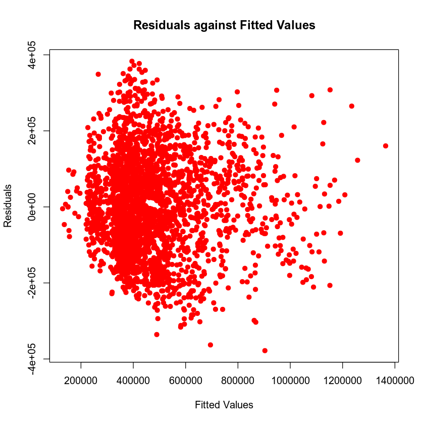

```r
plot(fitted_allmod, resids1_allmod,
     main = "Residuals against Fitted Values",
     xlab = "Fitted Values", ylab = "Residuals",
     col="red",
     pch = 19)
```

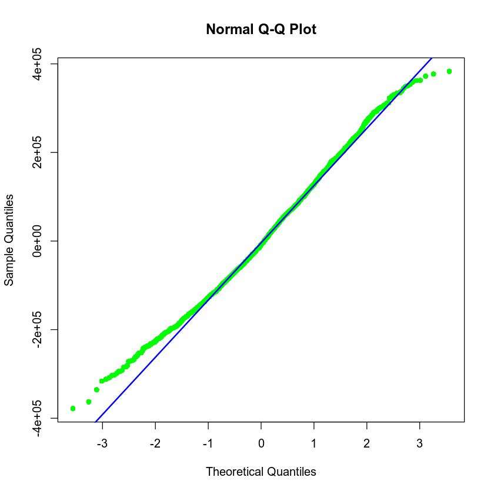

```r
qqnorm(resids1_allmod, pch = 16, col="green", frame = TRUE)
qqline(resids1_allmod, col = "blue", lwd = 2)
```

```r
all_model2 <- lm(price~sqft_living+grade+bathrooms,data=housing)
```

```r
newdata <- data.frame(sqft_living=2150, grade=7, bathrooms=3, view="2")

print("prediction interval")
prediction_pred_int <- predict(all_model, newdata, interval="predict", level=0.90)
round(prediction_pred_int, 4)

print("confidence interval")
prediction_conf_int <- predict(all_model, newdata, interval="confidence", level=0.90)
round(prediction_conf_int, 4)
```

```
[1] "prediction interval"
```

A matrix: 1 × 3 of type dbl

| fit | lwr | upr |
| --- | --- | --- |
| 630785.7 | 422684.5 | 838887 |

```
[1] "confidence interval"
```

A matrix: 1 × 3 of type dbl

| fit | lwr | upr |
| --- | --- | --- |
| 630785.7 | 610013.7 | 651557.7 |

```r
newdata <- data.frame(sqft_living=2150, grade=7, bathrooms=3)

print("prediction interval")
prediction_pred_int <- predict(all_model2, newdata, interval="predict", level=0.90)
round(prediction_pred_int, 4)

print("confidence interval")
prediction_conf_int <- predict(all_model2, newdata, interval="confidence", level=0.90)
round(prediction_conf_int, 4)
```

```
[1] "prediction interval"
```

A matrix: 1 × 3 of type dbl

| fit | lwr | upr |
| --- | --- | --- |
| 412811.2 | 184268.1 | 641354.2 |

```
[1] "confidence interval"
```

A matrix: 1 × 3 of type dbl

| fit | lwr | upr |
| --- | --- | --- |
| 412811.2 | 401996.2 | 423626.2 |

# Model #2 - Complete Second Order Regression Model with Quantitative Variables

You have been asked to create a complete second order regression model for *price* as the response variable, and *appliance_age* and *crime* as predictor variables. Before writing any code, review Section 4 of the Summary Report template to see the questions you will be answering about your complete second order multiple regression model.

Run your scripts to get the outputs of your regression analysis. Then use the outputs to answer the questions in your summary report.

**Note: Use the + (plus) button to add new code blocks, if needed.**

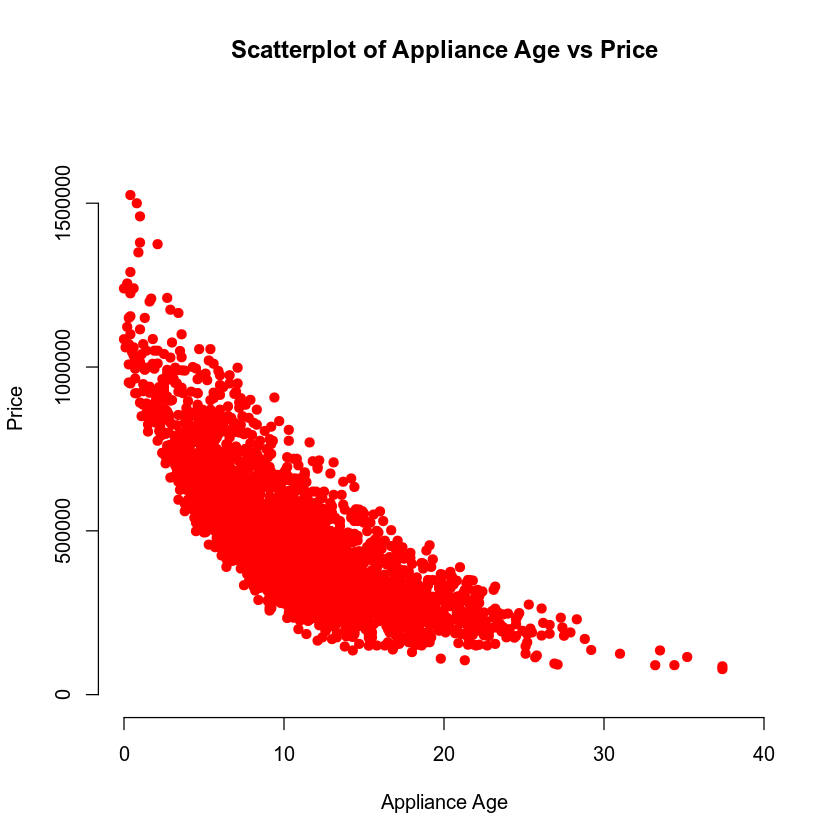

```r
plot(housing$appliance_age, housing$price,
     main = "Scatterplot of Appliance Age vs Price",
     xlab = "Appliance Age", ylab = "Price",
     xlim=c(0, 40),
     ylim=c(0, 1750000),
     col="red",
     pch = 19, frame = FALSE)
```

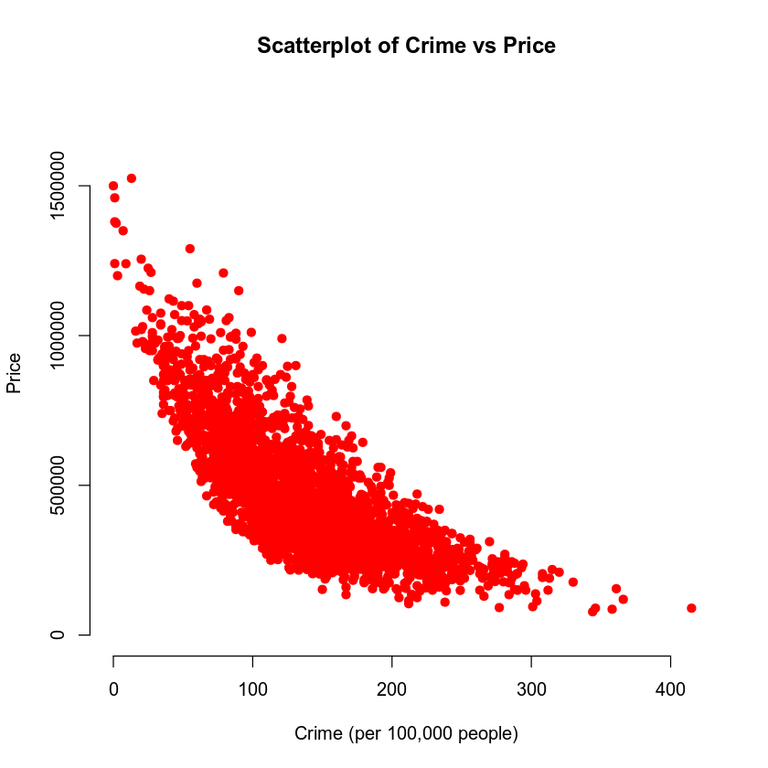

```r
plot(housing$crime, housing$price,
     main = "Scatterplot of Crime vs Price",
     xlab = "Crime (per 100,000 people)", ylab = "Price",
     xlim=c(0, 420),
     ylim=c(0, 1750000),
     col="red",
     pch = 19, frame = FALSE)
```

```r
higher_model <- lm(price ~ appliance_age + crime + appliance_age:crime + I(appliance_age^2) + I(crime^2), data=housing)
summary(higher_model)
```

```
Call:
lm(formula = price ~ appliance_age + crime + appliance_age:crime +
    I(appliance_age^2) + I(crime^2), data = housing)

Residuals:
    Min      1Q  Median      3Q     Max
-340502  -61196   -6241   57054  427449

Coefficients:
                      Estimate Std. Error t value Pr(>|t|)
(Intercept)          1.161e+06  9.116e+03 127.376   <2e-16 ***
appliance_age       -4.256e+04  1.375e+03 -30.951   <2e-16 ***
crime               -3.678e+03  1.481e+02 -24.827   <2e-16 ***
I(appliance_age^2)   8.330e+02  7.933e+01  10.501   <2e-16 ***
I(crime^2)           6.380e+00  7.265e-01   8.782   <2e-16 ***
appliance_age:crime  1.390e+01  1.298e+01   1.072    0.284
---
Signif. codes:  0 '***' 0.001 '**' 0.01 '*' 0.05 '.' 0.1 ' ' 1

Residual standard error: 92690 on 2686 degrees of freedom
Multiple R-squared:  0.8088,	Adjusted R-squared:  0.8084
F-statistic:  2272 on 5 and 2686 DF,  p-value: < 2.2e-16
```

```r
fitted_values <- fitted.values(higher_model)
fitted_values
```

**3**

569235.0849228

**4**

424598.603467736

**5**

619533.461283611

**6**

276829.115973261

**7**

311298.676921726

**8**

677782.148855022

**9**

218402.036492838

**10**

808787.204439934

**11**

315681.742208951

**12**

345132.212383106

**13**

412825.571397856

**14**

212757.226251324

**15**

375093.926415667

**16**

465565.393217053

**17**

653653.587977317

**18**

800454.454688162

**19**

430039.19999406

**20**

342170.984037768

**21**

398482.777229312

**22**

272703.627695901

**23**

473566.197553714

**24**

478144.365309197

**25**

787332.053232917

**26**

356575.450900152

**27**

581620.308205888

**28**

502877.544522187

**29**

845997.528618688

**30**

519268.153845891

**31**

177494.274751017

**32**

329238.25960244

**33**

692510.210034372

**34**

489555.973473206

**35**

457356.283477718

**36**

425585.166097756

**37**

473982.409875873

**38**

509744.927168996

**39**

591759.856561104

**40**

626570.956630116

**41**

718135.963081307

**42**

368943.356170415

**43**

225399.859588749

**44**

358277.744760494

**45**

332870.28837821

**46**

504825.133938776

**47**

354930.216414604

**48**

394328.061579809

**49**

333377.245122473

**50**

257849.218104506

**51**

452795.039518717

**52**

336463.126426893

**53**

243922.888806351

**54**

303075.492506196

**55**

375565.381321137

**56**

205462.62135039

**57**

415139.65981239

**58**

729024.675442865

**59**

784342.015127741

**60**

336635.738415588

**61**

404694.000459227

**62**

436620.189032792

**63**

643293.116613745

**64**

623691.392698652

**65**

516721.547542175

**66**

579081.88741539

**67**

397582.339032314

**68**

621697.080293694

**69**

811682.457784015

**70**

230828.354394971

**71**

390841.730669842

**72**

857695.943523378

**73**

471022.503486203

**74**

657096.271767865

**75**

339314.670785832

**76**

875310.734184631

**77**

397156.870927759

**78**

717775.306247457

**79**

653877.873232553

**80**

643503.397379513

**81**

417966.919958561

**82**

281543.178369809

**83**

350184.51039674

**84**

474536.129551891

**85**

695336.866629593

**86**

421811.114181184

**87**

518902.167634359

**88**

529137.387075502

**89**

402834.201249934

**90**

261751.069272834

**91**

284335.909475511

**92**

774189.45117906

**93**

215490.914728402

**94**

592798.664971247

**95**

463726.399321419

**96**

603572.282731201

**97**

545520.080290288

**98**

561413.479582379

**99**

663654.36140273

**100**

723770.846202145

**101**

246451.463788

**102**

340683.063058725

**103**

484982.431127692

**104**

272528.589433104

**105**

274311.880840336

**106**

810038.00950707

**107**

603881.173025039

**108**

331506.594018236

**109**

501866.267925282

**110**

338631.494484157

**111**

550102.481811533

**112**

338569.847397789

**113**

400194.693281119

**114**

281674.013303283

**115**

702145.356349846

**116**

759575.264304676

**117**

461754.157990786

**118**

720985.433237078

**119**

372928.510903646

**120**

418803.778229254

**121**

656360.677563157

**122**

399722.461716021

**123**

187050.716083165

**124**

423177.619522293

**125**

280259.523625828

**126**

671440.030170555

**127**

290099.170319761

**128**

407643.551298232

**129**

647245.723037066

**130**

738921.914815626

**131**

215994.617716247

**132**

436712.463416378

**133**

994319.266984394

**134**

365304.224831948

**135**

559809.088091401

**136**

602576.537815067

**137**

416316.268430353

**138**

531743.359276527

**139**

537626.367573694

**140**

369422.7799122

**141**

305025.676423024

**142**

313294.559297936

**143**

373652.918396615

**144**

363522.811207513

**145**

440079.366053891

**146**

639426.596065823

**147**

395580.638723779

**148**

494465.178849276

**149**

360546.306181961

**150**

546028.526527748

**151**

357351.567783612

**152**

187851.665856858

**153**

745152.353789935

**154**

338477.435862277

**155**

507453.072038697

**156**

504831.65756933

**157**

338372.735519987

**158**

192709.733755152

**159**

216676.432524986

**160**

533972.692505902

**161**

316289.514350178

**162**

332212.081205489

**163**

542330.291540509

**164**

898493.682866383

**165**

272318.254068354

**166**

280639.631522333

**167**

549306.581991225

**168**

228151.948131649

**169**

593499.647691199

**170**

751504.0923456

**171**

474666.990549933

**172**

275165.284891802

**173**

567905.366690813

**174**

735545.695995207

**175**

538419.773393139

**176**

224520.226120994

**177**

592905.485224648

**178**

394600.82669197

**179**

357813.989769269

**180**

275775.243202607

**181**

213237.328821925

**182**

193815.047472711

**183**

343029.815737277

**184**

580233.086653637

**185**

503853.220476409

**186**

704973.116912361

**187**

668735.93785678

**188**

539447.907085116

**189**

494052.795725801

**190**

503140.685895927

**191**

276049.053337972

**192**

281449.503951704

**193**

238252.951011452

**194**

792568.9756922

**195**

400101.045482578

**196**

861185.837043498

**197**

208949.940368652

**198**

203652.220584319

**199**

284478.173019734

**200**

275920.261502768

**201**

329568.006592085

**202**

488113.819166798

**203**

340417.835476623

**204**

651807.188551443

**205**

329284.617888944

**206**

446760.669004242

**207**

367103.662436528

**208**

793409.54260516

**209**

464920.773453176

**210**

472884.549338737

**211**

260601.007148846

**212**

584977.787958315

**213**

434656.018014327

**214**

797244.079723499

**215**

251274.39028319

**216**

247491.365831838

**217**

500313.933129219

**218**

612327.59527564

**219**

358353.731903201

**220**

238864.224689073

**221**

414029.320077529

**222**

293081.359380858

**223**

312918.086454717

**224**

363376.673755293

**225**

396991.342369452

**226**

749969.394376502

**227**

206810.719496341

**228**

304146.337471644

**229**

672087.336681753

**230**

317696.332067659

**231**

324634.188214005

**232**

401751.925554725

**233**

419167.895656896

**234**

521431.861780552

**235**

361129.168476227

**236**

702321.552019559

**237**

345327.779009275

**238**

659336.301450996

**239**

212905.086974632

**240**

531756.580479012

**241**

568104.653370444

**242**

561202.462510048

**243**

923913.627618511

**244**

178721.758654537

**245**

524410.541495984

**246**

544613.353380723

**247**

329205.877431703

**248**

542501.197293879

**249**

195326.225615835

**250**

392438.172769155

**251**

460175.817837434

**252**

190286.49157206

**253**

429248.24724371

**254**

232955.511209315

**255**

895824.455557715

**256**

347171.818609438

**257**

475153.179608299

**258**

623440.975339292

**259**

363153.360829877

**260**

430070.495972679

**261**

229593.905250784

**262**

763042.962321878

**263**

412285.212440732

**264**

776157.647351261

**265**

426428.079020016

**266**

228788.919819848

**267**

417375.689679205

**268**

711154.563330696

**269**

429961.382804075

**270**

398244.007132835

**271**

514192.659361379

**272**

543207.897140531

**273**

302367.75828198

**274**

241064.210289147

**275**

251471.047111431

**276**

409239.393642437

**277**

498591.933971387

**278**

266085.225763967

**279**

1075414.26190012

**280**

192743.067275153

**281**

397178.128995

**282**

469776.8366202

**283**

256568.714855664

**284**

768024.382940118

**285**

477007.095235324

**286**

495687.972532733

**287**

319906.262020395

**288**

462916.203148472

**289**

380889.892777131

**290**

738288.768288491

**291**

410615.844348194

**292**

444500.471806099

**293**

711149.421282162

**294**

201362.481668097

**295**

293526.974331682

**296**

361931.932572316

**297**

543275.205542042